# Developing a cryopreservation protocol for the forest-forming seaweed *Phyllospora comosa* as a tool for restoration

## **4d)** Statistical analyses

### Germling counts

#### i) Survival E3

```r
CountTox_percent6$Day <- as.factor(CountTox_percent6$Day)
CountTox_percent6_analysis <- filter(CountTox_percent6, Day != "0")
model <- lmer(sqrt(Percent_survival) ~ Day*Treatment + (1|Female), data = CountTox_percent6_analysis)
summary(model)
```

```
## Linear mixed model fit by REML ['lmerMod']
## Formula: sqrt(Percent_survival) ~ Day * Treatment + (1 | Female)
##    Data: CountTox_percent6_analysis
##
## REML criterion at convergence: 311.7
##
## Scaled residuals:
##     Min      1Q  Median      3Q     Max
## -3.6872 -0.1582  0.0643  0.1954  4.0412
##
## Random effects:
##  Groups   Name        Variance Std.Dev.
##  Female   (Intercept) 0.1237   0.3517
##  Residual             2.8777   1.6964
## Number of obs: 90, groups:  Female, 5
##
## Fixed effects:
##                           Estimate Std. Error t value
## (Intercept)              1.000e+01  7.748e-01  12.907
## Day7                     5.958e-15  1.073e+00   0.000
## Day14                   -1.492e-01  1.073e+00  -0.139
## TreatmentDMSO 10%       -2.387e-15  1.073e+00   0.000
## TreatmentEG 10%         -6.155e-02  1.073e+00  -0.057
## TreatmentFSW            -6.559e-02  1.073e+00  -0.061
## TreatmentGly 10%        -2.111e-01  1.073e+00  -0.197
## TreatmentPG 10%         -2.003e-01  1.073e+00  -0.187
## Day7:TreatmentDMSO 10%  -1.108e+00  1.517e+00  -0.730
## Day14:TreatmentDMSO 10% -1.642e+00  1.517e+00  -1.082
## Day7:TreatmentEG 10%    -7.399e+00  1.517e+00  -4.876
## Day14:TreatmentEG 10%   -7.124e+00  1.517e+00  -4.696
## Day7:TreatmentFSW       -3.364e-02  1.517e+00  -0.022
## Day14:TreatmentFSW       1.050e-01  1.517e+00   0.069
## Day7:TreatmentGly 10%   -7.894e-15  1.517e+00   0.000
## Day14:TreatmentGly 10%  -1.114e-01  1.517e+00  -0.073
## Day7:TreatmentPG 10%    -1.613e-01  1.517e+00  -0.106
## Day14:TreatmentPG 10%    1.766e-01  1.517e+00   0.116
```

```
##
## Correlation matrix not shown by default, as p = 18 > 12.
## Use print(x, correlation=TRUE)  or
##     vcov(x)        if you need it
```

```r
car::Anova(model)
```

```
## Analysis of Deviance Table (Type II Wald chisquare tests)
##
## Response: sqrt(Percent_survival)
##                Chisq Df Pr(>Chisq)
## Day           16.067  2  0.0003245 ***
## Treatment     95.667  5  < 2.2e-16 ***
## Day:Treatment 49.273 10  3.629e-07 ***
## ---
## Signif. codes:  0 '***' 0.001 '**' 0.01 '*' 0.05 '.' 0.1 ' ' 1
```

Contrasts:

```r
emmeans(model, specs = pairwise ~ Treatment|Day, type = "response", adjust = "none")
```

```
## $emmeans
## Day = 1:
##  Treatment response    SE df lower.CL upper.CL
##  Control     100.00 15.50 70   71.483    133.3
##  DMSO 10%    100.00 15.50 70   71.483    133.3
##  EG 10%       98.77 15.40 70   70.446    131.9
##  FSW          98.69 15.39 70   70.378    131.8
##  Gly 10%      95.82 15.17 70   67.957    128.5
##  PG 10%       96.03 15.19 70   68.136    128.7
##
## Day = 7:
##  Treatment response    SE df lower.CL upper.CL
##  Control     100.00 15.50 70   71.483    133.3
##  DMSO 10%     79.06 13.78 70   53.970    108.9
##  EG 10%        6.45  3.94 70    0.989     16.7
##  FSW          98.03 15.34 70   69.815    131.0
##  Gly 10%      95.82 15.17 70   67.957    128.5
##  PG 10%       92.90 14.94 70   65.498    125.1
##
## Day = 14:
##  Treatment response    SE df lower.CL upper.CL
##  Control      97.04 15.26 70   68.982    129.9
##  DMSO 10%     67.38 12.72 70   44.400     95.1
##  EG 10%        7.10  4.13 70    1.253     17.7
##  FSW          97.82 15.33 70   69.638    130.8
##  Gly 10%      90.79 14.76 70   63.729    122.6
##  PG 10%       96.57 15.23 70   68.589    129.3
##
## Degrees-of-freedom method: kenward-roger
## Confidence level used: 0.95
## Intervals are back-transformed from the sqrt scale
##
## $contrasts
## Day = 1:
##  contrast           estimate   SE df t.ratio p.value
##  Control - DMSO 10%  0.00000 1.07 68   0.000  1.0000
##  Control - EG 10%    0.06155 1.07 68   0.057  0.9544
##  Control - FSW       0.06559 1.07 68   0.061  0.9514
##  Control - Gly 10%   0.21115 1.07 68   0.197  0.8446
##  Control - PG 10%    0.20032 1.07 68   0.187  0.8524
```

[output cut: 34 more lines]

```
##  Control - Gly 10%   0.32250 1.07 68   0.301  0.7646
##  Control - PG 10%    0.02369 1.07 68   0.022  0.9825
##  DMSO 10% - EG 10%   5.54372 1.07 68   5.167  <.0001
##  DMSO 10% - FSW     -1.68165 1.07 68  -1.567  0.1217
##  DMSO 10% - Gly 10% -1.31975 1.07 68  -1.230  0.2229
##  DMSO 10% - PG 10%  -1.61856 1.07 68  -1.509  0.1360
##  EG 10% - FSW       -7.22537 1.07 68  -6.735  <.0001
##  EG 10% - Gly 10%   -6.86347 1.07 68  -6.397  <.0001
##  EG 10% - PG 10%    -7.16229 1.07 68  -6.676  <.0001
##  FSW - Gly 10%       0.36190 1.07 68   0.337  0.7369
##  FSW - PG 10%        0.06308 1.07 68   0.059  0.9533
##  Gly 10% - PG 10%   -0.29881 1.07 68  -0.279  0.7815
##
## Note: contrasts are still on the sqrt scale
## Degrees-of-freedom method: kenward-roger
```

Check model assumptions:

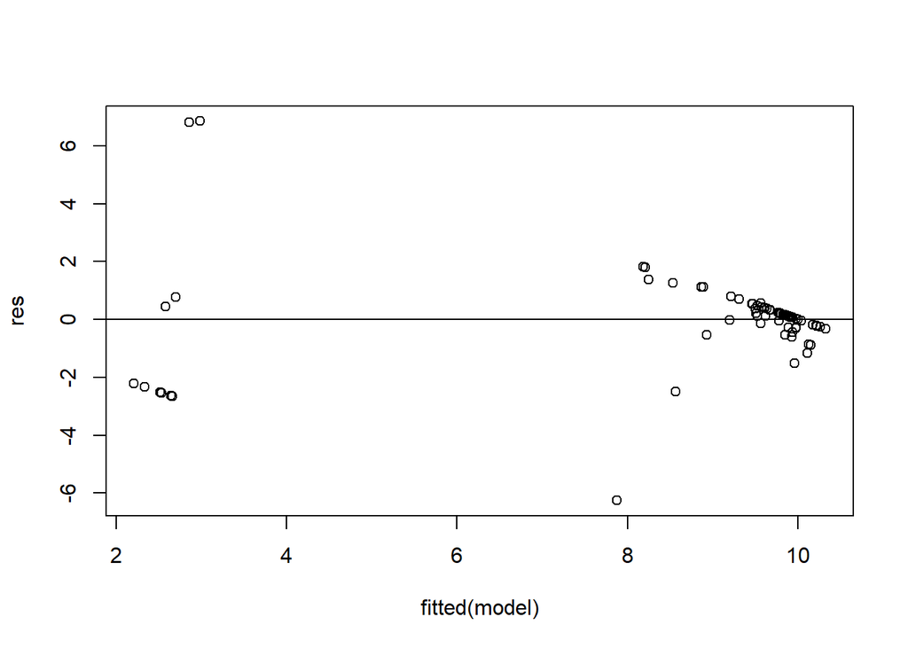

```r
res <- resid(model)

#produce residual vs. fitted plot
plot(fitted(model), res)

#add a horizontal line at 0
abline(0,0)
```

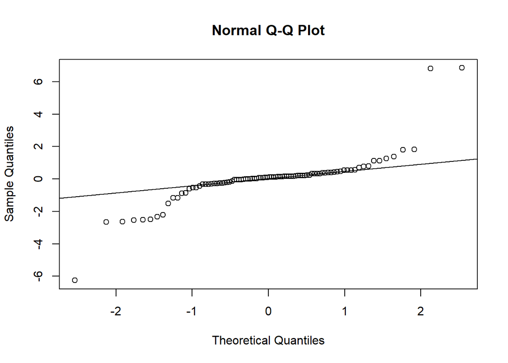

```r
#create Q-Q plot for residuals
qqnorm(res)

#add a straight diagonal line to the plot
qqline(res)
```

#### ii) Survival E3-v2

```r
CountTox_percent7$Day <- as.factor(CountTox_percent7$Day)
CountTox_percent7_analysis <- filter(CountTox_percent7, Day == "7"| Day == "14")
model <- lmer(sqrt(Percent_survival) ~ Day*Treatment + (1|Female), data = CountTox_percent7_analysis)
```

```
## boundary (singular) fit: see help('isSingular')
```

```r
summary(model)
```

```
## Linear mixed model fit by REML ['lmerMod']
## Formula: sqrt(Percent_survival) ~ Day * Treatment + (1 | Female)
##    Data: CountTox_percent7_analysis
##
## REML criterion at convergence: 108.6
##
## Scaled residuals:
##     Min      1Q  Median      3Q     Max
## -3.6479 -0.1850  0.0512  0.1895  2.0151
##
## Random effects:
##  Groups   Name        Variance Std.Dev.
##  Female   (Intercept) 0.000    0.000
##  Residual             3.118    1.766
## Number of obs: 36, groups:  Female, 3
##
## Fixed effects:
##                         Estimate Std. Error t value
## (Intercept)              9.85809    1.01951   9.669
## Day14                   -0.06735    1.44181  -0.047
## TreatmentDMSO 10%       -0.27435    1.44181  -0.190
## TreatmentEG 10%         -9.16304    1.44181  -6.355
## TreatmentFSW            -1.21513    1.44181  -0.843
## TreatmentGly 10%        -0.39358    1.44181  -0.273
## TreatmentPG 10%         -0.91783    1.44181  -0.637
## Day14:TreatmentDMSO 10%  0.19318    2.03903   0.095
## Day14:TreatmentEG 10%   -0.62770    2.03903  -0.308
## Day14:TreatmentFSW       0.53705    2.03903   0.263
## Day14:TreatmentGly 10%   0.42953    2.03903   0.211
## Day14:TreatmentPG 10%   -2.43123    2.03903  -1.192
##
## Correlation of Fixed Effects:
##             (Intr) Day14  TDMSO1 TEG10% TrtFSW TrG10% TPG10% D14:TD1 D14:TE1
## Day14       -0.707
## TrtmDMSO10% -0.707  0.500
## TrtmntEG10% -0.707  0.500  0.500
## TreatmntFSW -0.707  0.500  0.500  0.500
## TrtmntGl10% -0.707  0.500  0.500  0.500  0.500
## TrtmntPG10% -0.707  0.500  0.500  0.500  0.500  0.500
## D14:TDMSO10  0.500 -0.707 -0.707 -0.354 -0.354 -0.354 -0.354
## Dy14:TEG10%  0.500 -0.707 -0.354 -0.707 -0.354 -0.354 -0.354  0.500
## Dy14:TrtFSW  0.500 -0.707 -0.354 -0.354 -0.707 -0.354 -0.354  0.500   0.500
## Dy14:TrG10%  0.500 -0.707 -0.354 -0.354 -0.354 -0.707 -0.354  0.500   0.500
## Dy14:TPG10%  0.500 -0.707 -0.354 -0.354 -0.354 -0.354 -0.707  0.500   0.500
##             D14:TF D14:TG1
## Day14
## TrtmDMSO10%
## TrtmntEG10%
## TreatmntFSW
## TrtmntGl10%
## TrtmntPG10%
## D14:TDMSO10
## Dy14:TEG10%
## Dy14:TrtFSW
## Dy14:TrG10%  0.500
## Dy14:TPG10%  0.500  0.500
## optimizer (nloptwrap) convergence code: 0 (OK)
## boundary (singular) fit: see help('isSingular')
```

```r
car::Anova(model)
```

```
## Analysis of Deviance Table (Type II Wald chisquare tests)
##
## Response: sqrt(Percent_survival)
##                  Chisq Df Pr(>Chisq)
## Day             0.4253  1     0.5143
## Treatment     129.9384  5     <2e-16 ***
## Day:Treatment   2.9892  5     0.7017
## ---
## Signif. codes:  0 '***' 0.001 '**' 0.01 '*' 0.05 '.' 0.1 ' ' 1
```

Contrasts:

```r
emmeans(model, specs = pairwise ~ Treatment, type = "response", adjust = "none")
```

```
## NOTE: Results may be misleading due to involvement in interactions
```

```
## $emmeans
##  Treatment response     SE df lower.CL upper.CL
##  Control     96.519 14.165 22     69.4    128.1
##  DMSO 10%    93.058 13.909 22     66.4    124.1
##  EG 10%       0.121  0.501 22      0.0      3.4
##  FSW         78.816 12.800 22     54.5    107.6
##  Gly 10%     93.038 13.907 22     66.4    124.1
##  PG 10%      59.151 11.089 22     38.4     84.4
##
## Results are averaged over the levels of: Day
## Degrees-of-freedom method: kenward-roger
## Confidence level used: 0.95
## Intervals are back-transformed from the sqrt scale
##
## $contrasts
##  contrast           estimate   SE df t.ratio p.value
##  Control - DMSO 10%  0.17776 1.02 22   0.174  0.8632
##  Control - EG 10%    9.47689 1.02 22   9.296  <.0001
##  Control - FSW       0.94660 1.02 22   0.928  0.3632
##  Control - Gly 10%   0.17881 1.02 22   0.175  0.8624
##  Control - PG 10%    2.13344 1.02 22   2.093  0.0481
##  DMSO 10% - EG 10%   9.29913 1.02 22   9.121  <.0001
##  DMSO 10% - FSW      0.76884 1.02 22   0.754  0.4588
##  DMSO 10% - Gly 10%  0.00105 1.02 22   0.001  0.9992
##  DMSO 10% - PG 10%   1.95568 1.02 22   1.918  0.0682
##  EG 10% - FSW       -8.53029 1.02 22  -8.367  <.0001
##  EG 10% - Gly 10%   -9.29808 1.02 22  -9.120  <.0001
##  EG 10% - PG 10%    -7.34345 1.02 22  -7.203  <.0001
##  FSW - Gly 10%      -0.76779 1.02 22  -0.753  0.4594
##  FSW - PG 10%        1.18684 1.02 22   1.164  0.2568
##  Gly 10% - PG 10%    1.95463 1.02 22   1.917  0.0683
##
## Results are averaged over the levels of: Day
## Note: contrasts are still on the sqrt scale
## Degrees-of-freedom method: kenward-roger
```

Check model assumptions:

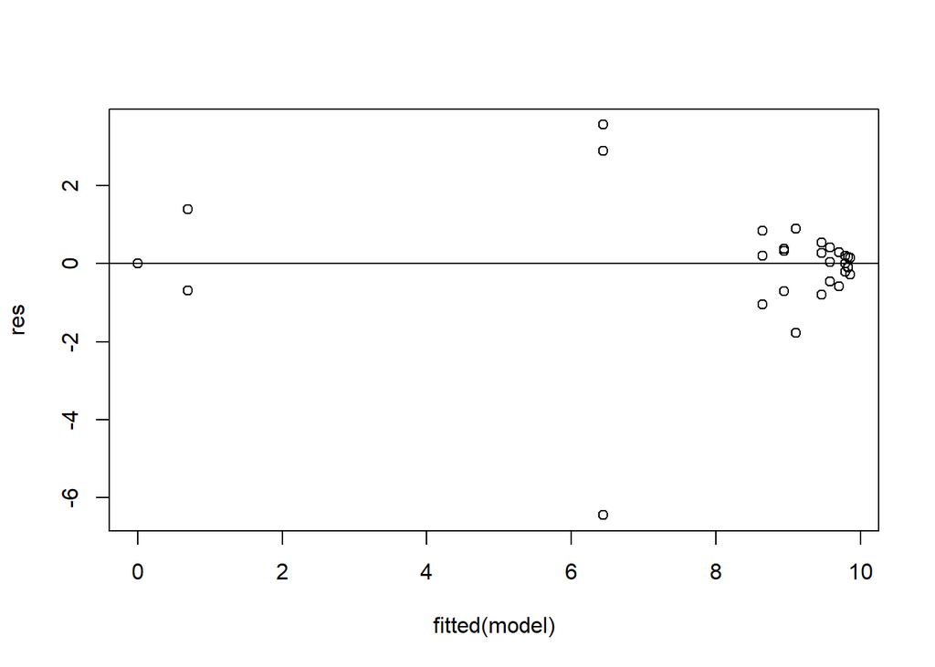

```r
res <- resid(model)

#produce residual vs. fitted plot
plot(fitted(model), res)

#add a horizontal line at 0
abline(0,0)
```

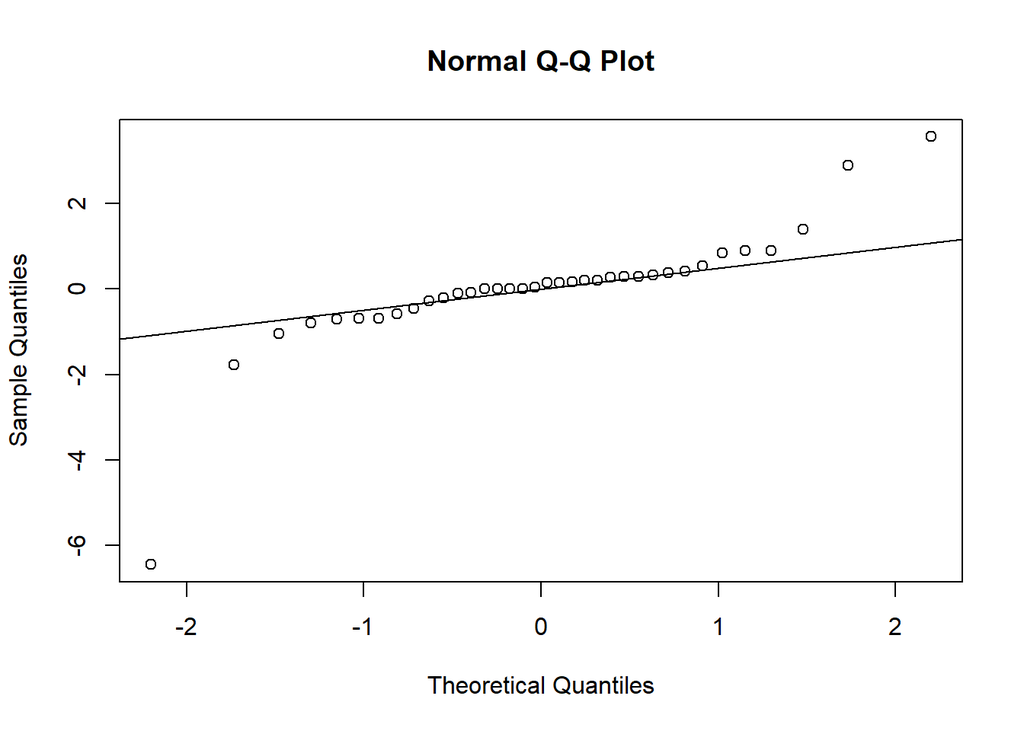

```r
#create Q-Q plot for residuals
qqnorm(res)

#add a straight diagonal line to the plot
qqline(res)
```

### Germling size

#### i. Length

```r
model <- lmer(sqrt(Length) ~ Day*Treatment + (1|Female), data = Lengths_tox)
summary(model)
```

```
## Linear mixed model fit by REML ['lmerMod']
## Formula: sqrt(Length) ~ Day * Treatment + (1 | Female)
##    Data: Lengths_tox
##
## REML criterion at convergence: -230.5
##
## Scaled residuals:
##      Min       1Q   Median       3Q      Max
## -2.41488 -0.49257  0.00237  0.53831  2.17500
##
## Random effects:
##  Groups   Name        Variance  Std.Dev.
##  Female   (Intercept) 4.133e-05 0.006429
##  Residual             1.148e-03 0.033882
## Number of obs: 84, groups:  Female, 5
##
## Fixed effects:
##                           Estimate Std. Error t value
## (Intercept)              5.337e-01  1.542e-02  34.606
## Day7                     2.178e-01  2.143e-02  10.164
## Day14                    2.233e-01  2.143e-02  10.421
## TreatmentDMSO 10%       -6.669e-03  2.143e-02  -0.311
## TreatmentEG 10%          5.351e-05  2.143e-02   0.002
## TreatmentFSW            -5.126e-03  2.143e-02  -0.239
## TreatmentGly 10%        -2.186e-02  2.143e-02  -1.020
## TreatmentPG 10%         -3.733e-04  2.143e-02  -0.017
## Day7:TreatmentDMSO 10%  -1.214e-01  3.031e-02  -4.007
## Day14:TreatmentDMSO 10% -1.002e-01  3.031e-02  -3.306
## Day7:TreatmentEG 10%    -1.161e-01  3.565e-02  -3.257
## Day14:TreatmentEG 10%   -5.816e-02  3.565e-02  -1.632
## Day7:TreatmentFSW       -6.060e-02  3.031e-02  -2.000
## Day14:TreatmentFSW      -2.539e-02  3.031e-02  -0.838
## Day7:TreatmentGly 10%   -8.201e-02  3.031e-02  -2.706
## Day14:TreatmentGly 10%  -8.292e-02  3.031e-02  -2.736
## Day7:TreatmentPG 10%    -6.508e-02  3.031e-02  -2.147
## Day14:TreatmentPG 10%   -4.718e-02  3.031e-02  -1.557
```

```
##
## Correlation matrix not shown by default, as p = 18 > 12.
## Use print(x, correlation=TRUE)  or
##     vcov(x)        if you need it
```

```r
car::Anova(model)
```

```
## Analysis of Deviance Table (Type II Wald chisquare tests)
##
## Response: sqrt(Length)
##                 Chisq Df Pr(>Chisq)
## Day           420.387  2  < 2.2e-16 ***
## Treatment      58.772  5  2.179e-11 ***
## Day:Treatment  25.189 10   0.004998 **
## ---
## Signif. codes:  0 '***' 0.001 '**' 0.01 '*' 0.05 '.' 0.1 ' ' 1
```

Contrasts:

```r
emmeans(model, specs = pairwise ~ Treatment|Day, type = "response", adjust = "none")
```

```
## $emmeans
## Day = 0:
##  Treatment response     SE   df lower.CL upper.CL
##  Control      0.285 0.0165 64.8    0.253    0.319
##  DMSO 10%     0.278 0.0163 64.8    0.246    0.311
##  EG 10%       0.285 0.0165 64.8    0.253    0.319
##  FSW          0.279 0.0163 64.8    0.248    0.313
##  Gly 10%      0.262 0.0158 64.8    0.231    0.294
##  PG 10%       0.284 0.0165 64.8    0.253    0.318
##
## Day = 7:
##  Treatment response     SE   df lower.CL upper.CL
##  Control      0.565 0.0232 64.8    0.519    0.612
##  DMSO 10%     0.389 0.0192 64.8    0.351    0.428
##  EG 10%       0.404 0.0312 66.0    0.344    0.469
##  FSW          0.470 0.0212 64.8    0.429    0.514
##  Gly 10%      0.419 0.0200 64.8    0.381    0.460
##  PG 10%       0.471 0.0212 64.8    0.429    0.514
##
## Day = 14:
##  Treatment response     SE   df lower.CL upper.CL
##  Control      0.573 0.0234 64.8    0.527    0.621
##  DMSO 10%     0.423 0.0201 64.8    0.384    0.464
##  EG 10%       0.489 0.0344 66.0    0.422    0.560
##  FSW          0.528 0.0224 64.8    0.484    0.574
##  Gly 10%      0.425 0.0201 64.8    0.386    0.467
##  PG 10%       0.503 0.0219 64.8    0.461    0.548
##
## Degrees-of-freedom method: kenward-roger
## Confidence level used: 0.95
## Intervals are back-transformed from the sqrt scale
##
## $contrasts
## Day = 0:
##  contrast            estimate     SE   df t.ratio p.value
##  Control - DMSO 10%  6.67e-03 0.0214 62.0   0.311  0.7567
##  Control - EG 10%   -5.35e-05 0.0214 62.0  -0.002  0.9980
##  Control - FSW       5.13e-03 0.0214 62.0   0.239  0.8117
##  Control - Gly 10%   2.19e-02 0.0214 62.0   1.020  0.3117
##  Control - PG 10%    3.73e-04 0.0214 62.0   0.017  0.9862
```

[output cut: 34 more lines]

```
##  Control - Gly 10%   1.05e-01 0.0214 62.0   4.889  <.0001
##  Control - PG 10%    4.76e-02 0.0214 62.0   2.219  0.0301
##  DMSO 10% - EG 10%  -4.88e-02 0.0287 63.8  -1.697  0.0945
##  DMSO 10% - FSW     -7.64e-02 0.0214 62.0  -3.563  0.0007
##  DMSO 10% - Gly 10% -2.10e-03 0.0214 62.0  -0.098  0.9224
##  DMSO 10% - PG 10%  -5.93e-02 0.0214 62.0  -2.768  0.0074
##  EG 10% - FSW       -2.76e-02 0.0287 63.8  -0.960  0.3405
##  EG 10% - Gly 10%    4.67e-02 0.0287 63.8   1.624  0.1093
##  EG 10% - PG 10%    -1.06e-02 0.0287 63.8  -0.367  0.7146
##  FSW - Gly 10%       7.43e-02 0.0214 62.0   3.465  0.0010
##  FSW - PG 10%        1.70e-02 0.0214 62.0   0.795  0.4295
##  Gly 10% - PG 10%   -5.72e-02 0.0214 62.0  -2.670  0.0097
##
## Note: contrasts are still on the sqrt scale
## Degrees-of-freedom method: kenward-roger
```

```r
emmeans(model, specs = pairwise ~ Day|Treatment, type = "response", adjust = "none")
```

```
## $emmeans
## Treatment = Control:
##  Day response     SE   df lower.CL upper.CL
##  0      0.285 0.0165 64.8    0.253    0.319
##  7      0.565 0.0232 64.8    0.519    0.612
##  14     0.573 0.0234 64.8    0.527    0.621
##
## Treatment = DMSO 10%:
##  Day response     SE   df lower.CL upper.CL
##  0      0.278 0.0163 64.8    0.246    0.311
##  7      0.389 0.0192 64.8    0.351    0.428
##  14     0.423 0.0201 64.8    0.384    0.464
##
## Treatment = EG 10%:
##  Day response     SE   df lower.CL upper.CL
##  0      0.285 0.0165 64.8    0.253    0.319
##  7      0.404 0.0312 66.0    0.344    0.469
##  14     0.489 0.0344 66.0    0.422    0.560
##
## Treatment = FSW:
##  Day response     SE   df lower.CL upper.CL
##  0      0.279 0.0163 64.8    0.248    0.313
##  7      0.470 0.0212 64.8    0.429    0.514
##  14     0.528 0.0224 64.8    0.484    0.574
##
## Treatment = Gly 10%:
##  Day response     SE   df lower.CL upper.CL
##  0      0.262 0.0158 64.8    0.231    0.294
##  7      0.419 0.0200 64.8    0.381    0.460
##  14     0.425 0.0201 64.8    0.386    0.467
##
## Treatment = PG 10%:
##  Day response     SE   df lower.CL upper.CL
##  0      0.284 0.0165 64.8    0.253    0.318
##  7      0.471 0.0212 64.8    0.429    0.514
##  14     0.503 0.0219 64.8    0.461    0.548
##
## Degrees-of-freedom method: kenward-roger
## Confidence level used: 0.95
## Intervals are back-transformed from the sqrt scale
```

[output cut: 25 more lines]

```
##
## Treatment = Gly 10%:
##  contrast     estimate     SE   df t.ratio p.value
##  Day0 - Day7  -0.13580 0.0214 62.0  -6.337  <.0001
##  Day0 - Day14 -0.14039 0.0214 62.0  -6.552  <.0001
##  Day7 - Day14 -0.00459 0.0214 62.0  -0.214  0.8310
##
## Treatment = PG 10%:
##  contrast     estimate     SE   df t.ratio p.value
##  Day0 - Day7  -0.15274 0.0214 62.0  -7.128  <.0001
##  Day0 - Day14 -0.17613 0.0214 62.0  -8.219  <.0001
##  Day7 - Day14 -0.02339 0.0214 62.0  -1.092  0.2792
##
## Note: contrasts are still on the sqrt scale
## Degrees-of-freedom method: kenward-roger
```

Check model assumptions:

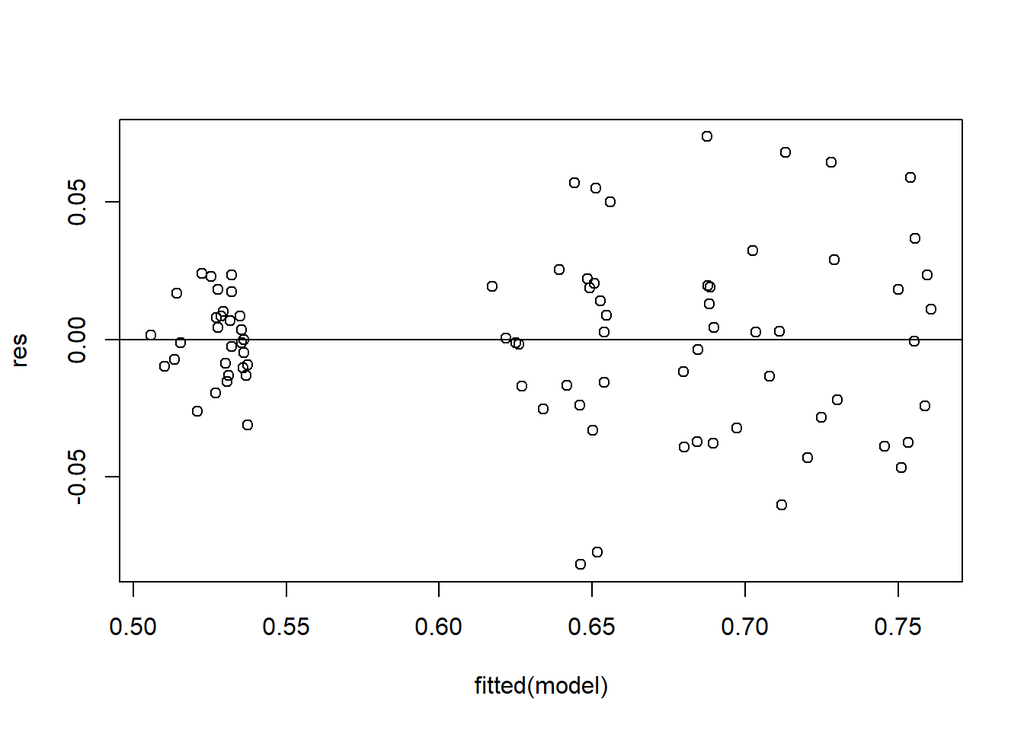

```r
res <- resid(model)

#produce residual vs. fitted plot
plot(fitted(model), res)

#add a horizontal line at 0
abline(0,0)
```

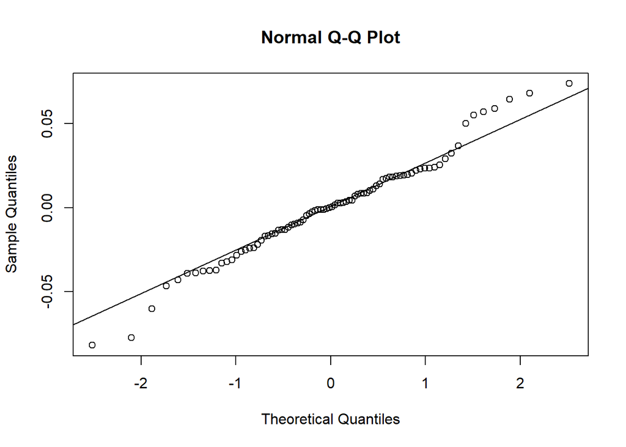

```r
#create Q-Q plot for residuals
qqnorm(res)

#add a straight diagonal line to the plot
qqline(res)
```

#### ii. Area

```r
model <- lmer(sqrt(Area) ~ Day*Treatment + (1|Female), data = Lengths_tox)
summary(model)
```

```
## Linear mixed model fit by REML ['lmerMod']
## Formula: sqrt(Area) ~ Day * Treatment + (1 | Female)
##    Data: Lengths_tox
##
## REML criterion at convergence: -282.2
##
## Scaled residuals:
##     Min      1Q  Median      3Q     Max
## -2.4811 -0.4207  0.0150  0.3208  3.4401
##
## Random effects:
##  Groups   Name        Variance  Std.Dev.
##  Female   (Intercept) 3.146e-05 0.005609
##  Residual             5.172e-04 0.022742
## Number of obs: 84, groups:  Female, 5
##
## Fixed effects:
##                           Estimate Std. Error t value
## (Intercept)              0.1782362  0.0104753  17.015
## Day7                     0.1170510  0.0143834   8.138
## Day14                    0.1397115  0.0143834   9.713
## TreatmentDMSO 10%       -0.0034248  0.0143834  -0.238
## TreatmentEG 10%          0.0003513  0.0143834   0.024
## TreatmentFSW            -0.0016654  0.0143834  -0.116
## TreatmentGly 10%        -0.0080563  0.0143834  -0.560
## TreatmentPG 10%         -0.0009530  0.0143834  -0.066
## Day7:TreatmentDMSO 10%  -0.0662789  0.0203412  -3.258
## Day14:TreatmentDMSO 10% -0.0758896  0.0203412  -3.731
## Day7:TreatmentEG 10%    -0.0628432  0.0239522  -2.624
## Day14:TreatmentEG 10%   -0.0623559  0.0239522  -2.603
## Day7:TreatmentFSW       -0.0349994  0.0203412  -1.721
## Day14:TreatmentFSW      -0.0374128  0.0203412  -1.839
## Day7:TreatmentGly 10%   -0.0467337  0.0203412  -2.297
## Day14:TreatmentGly 10%  -0.0701892  0.0203412  -3.451
## Day7:TreatmentPG 10%    -0.0357062  0.0203412  -1.755
## Day14:TreatmentPG 10%   -0.0466080  0.0203412  -2.291
```

```
##
## Correlation matrix not shown by default, as p = 18 > 12.
## Use print(x, correlation=TRUE)  or
##     vcov(x)        if you need it
```

```r
car::Anova(model)
```

```
## Analysis of Deviance Table (Type II Wald chisquare tests)
##
## Response: sqrt(Area)
##                 Chisq Df Pr(>Chisq)
## Day           265.642  2  < 2.2e-16 ***
## Treatment      48.300  5  3.085e-09 ***
## Day:Treatment  22.251 10    0.01387 *
## ---
## Signif. codes:  0 '***' 0.001 '**' 0.01 '*' 0.05 '.' 0.1 ' ' 1
```

Contrasts:

```r
emmeans(model, specs = pairwise ~ Treatment|Day, type = "response", adjust = "none")
```

```
## $emmeans
## Day = 0:
##  Treatment response      SE   df lower.CL upper.CL
##  Control     0.0318 0.00373 62.8   0.0247   0.0397
##  DMSO 10%    0.0306 0.00366 62.8   0.0237   0.0383
##  EG 10%      0.0319 0.00374 62.8   0.0249   0.0398
##  FSW         0.0312 0.00370 62.8   0.0242   0.0390
##  Gly 10%     0.0290 0.00357 62.8   0.0223   0.0365
##  PG 10%      0.0314 0.00371 62.8   0.0244   0.0393
##
## Day = 7:
##  Treatment response      SE   df lower.CL upper.CL
##  Control     0.0872 0.00619 62.8   0.0753   0.1000
##  DMSO 10%    0.0509 0.00473 62.8   0.0419   0.0608
##  EG 10%      0.0542 0.00772 66.0   0.0399   0.0707
##  FSW         0.0669 0.00542 62.8   0.0565   0.0782
##  Gly 10%     0.0578 0.00504 62.8   0.0482   0.0683
##  PG 10%      0.0669 0.00542 62.8   0.0565   0.0782
##
## Day = 14:
##  Treatment response      SE   df lower.CL upper.CL
##  Control     0.1011 0.00666 62.8   0.0882   0.1148
##  DMSO 10%    0.0569 0.00500 62.8   0.0474   0.0674
##  EG 10%      0.0655 0.00848 66.0   0.0497   0.0835
##  FSW         0.0778 0.00584 62.8   0.0665   0.0899
##  Gly 10%     0.0575 0.00502 62.8   0.0479   0.0679
##  PG 10%      0.0731 0.00566 62.8   0.0622   0.0849
##
## Degrees-of-freedom method: kenward-roger
## Confidence level used: 0.95
## Intervals are back-transformed from the sqrt scale
##
## $contrasts
## Day = 0:
##  contrast            estimate     SE   df t.ratio p.value
##  Control - DMSO 10%  3.42e-03 0.0144 62.0   0.238  0.8126
##  Control - EG 10%   -3.51e-04 0.0144 62.0  -0.024  0.9806
##  Control - FSW       1.67e-03 0.0144 62.0   0.116  0.9082
##  Control - Gly 10%   8.06e-03 0.0144 62.0   0.560  0.5774
##  Control - PG 10%    9.53e-04 0.0144 62.0   0.066  0.9474
```

[output cut: 34 more lines]

```
##  Control - Gly 10%   7.82e-02 0.0144 62.0   5.440  <.0001
##  Control - PG 10%    4.76e-02 0.0144 62.0   3.307  0.0016
##  DMSO 10% - EG 10%  -1.73e-02 0.0193 63.5  -0.898  0.3728
##  DMSO 10% - FSW     -4.02e-02 0.0144 62.0  -2.797  0.0069
##  DMSO 10% - Gly 10% -1.07e-03 0.0144 62.0  -0.074  0.9410
##  DMSO 10% - PG 10%  -3.18e-02 0.0144 62.0  -2.208  0.0310
##  EG 10% - FSW       -2.29e-02 0.0193 63.5  -1.189  0.2389
##  EG 10% - Gly 10%    1.62e-02 0.0193 63.5   0.842  0.4029
##  EG 10% - PG 10%    -1.44e-02 0.0193 63.5  -0.749  0.4566
##  FSW - Gly 10%       3.92e-02 0.0144 62.0   2.723  0.0084
##  FSW - PG 10%        8.48e-03 0.0144 62.0   0.590  0.5575
##  Gly 10% - PG 10%   -3.07e-02 0.0144 62.0  -2.133  0.0369
##
## Note: contrasts are still on the sqrt scale
## Degrees-of-freedom method: kenward-roger
```

```r
emmeans(model, specs = pairwise ~ Day|Treatment, type = "response", adjust = "none")
```

```
## $emmeans
## Treatment = Control:
##  Day response      SE   df lower.CL upper.CL
##  0     0.0318 0.00373 62.8   0.0247   0.0397
##  7     0.0872 0.00619 62.8   0.0753   0.1000
##  14    0.1011 0.00666 62.8   0.0882   0.1148
##
## Treatment = DMSO 10%:
##  Day response      SE   df lower.CL upper.CL
##  0     0.0306 0.00366 62.8   0.0237   0.0383
##  7     0.0509 0.00473 62.8   0.0419   0.0608
##  14    0.0569 0.00500 62.8   0.0474   0.0674
##
## Treatment = EG 10%:
##  Day response      SE   df lower.CL upper.CL
##  0     0.0319 0.00374 62.8   0.0249   0.0398
##  7     0.0542 0.00772 66.0   0.0399   0.0707
##  14    0.0655 0.00848 66.0   0.0497   0.0835
##
## Treatment = FSW:
##  Day response      SE   df lower.CL upper.CL
##  0     0.0312 0.00370 62.8   0.0242   0.0390
##  7     0.0669 0.00542 62.8   0.0565   0.0782
##  14    0.0778 0.00584 62.8   0.0665   0.0899
##
## Treatment = Gly 10%:
##  Day response      SE   df lower.CL upper.CL
##  0     0.0290 0.00357 62.8   0.0223   0.0365
##  7     0.0578 0.00504 62.8   0.0482   0.0683
##  14    0.0575 0.00502 62.8   0.0479   0.0679
##
## Treatment = PG 10%:
##  Day response      SE   df lower.CL upper.CL
##  0     0.0314 0.00371 62.8   0.0244   0.0393
##  7     0.0669 0.00542 62.8   0.0565   0.0782
##  14    0.0731 0.00566 62.8   0.0622   0.0849
##
## Degrees-of-freedom method: kenward-roger
## Confidence level used: 0.95
## Intervals are back-transformed from the sqrt scale
```

[output cut: 25 more lines]

```
##
## Treatment = Gly 10%:
##  contrast      estimate     SE   df t.ratio p.value
##  Day0 - Day7  -0.070317 0.0144 62.0  -4.889  <.0001
##  Day0 - Day14 -0.069522 0.0144 62.0  -4.834  <.0001
##  Day7 - Day14  0.000795 0.0144 62.0   0.055  0.9561
##
## Treatment = PG 10%:
##  contrast      estimate     SE   df t.ratio p.value
##  Day0 - Day7  -0.081345 0.0144 62.0  -5.655  <.0001
##  Day0 - Day14 -0.093104 0.0144 62.0  -6.473  <.0001
##  Day7 - Day14 -0.011759 0.0144 62.0  -0.818  0.4168
##
## Note: contrasts are still on the sqrt scale
## Degrees-of-freedom method: kenward-roger
```

Check model assumptions:

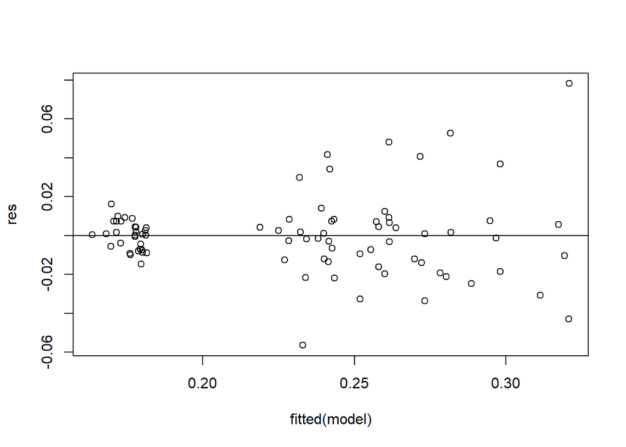

```r
res <- resid(model)

#produce residual vs. fitted plot
plot(fitted(model), res)

#add a horizontal line at 0
abline(0,0)
```

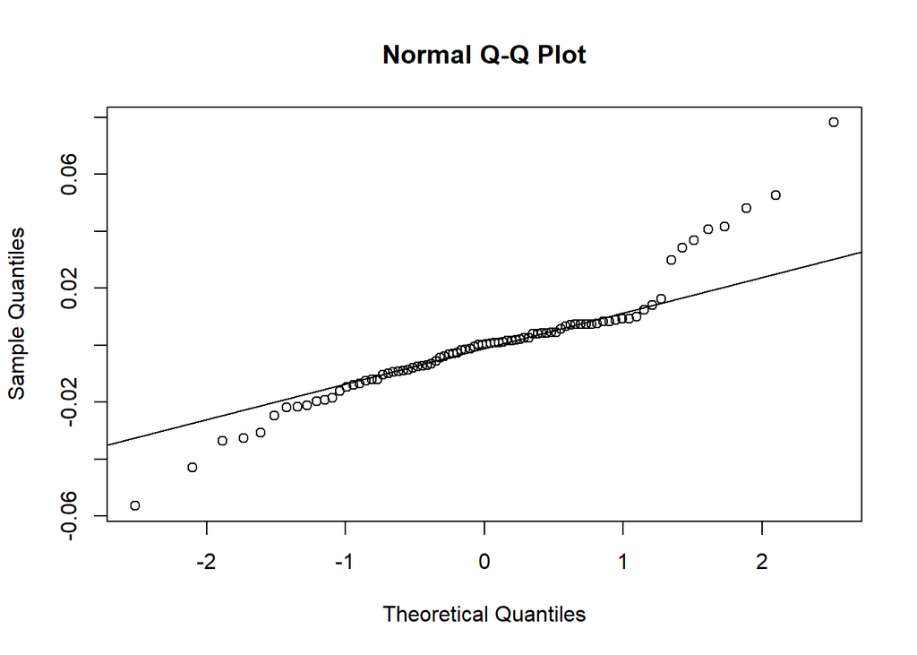

```r
#create Q-Q plot for residuals
qqnorm(res)

#add a straight diagonal line to the plot
qqline(res)
```

# **5.** Experiment 4: Germling viability after thawing

## **5a)** Import data

```r
Thawed5Aug <- read.csv("Data_cryo/Germling_thawed_5aug2024.csv")
```

## **5b)** Data structure and summary

1. Check structure

```r
str(Thawed5Aug)
```

```
## 'data.frame':    187 obs. of  18 variables:
##  $ Method            : chr  "Straw" "Straw" "Straw" "Straw" ...
##  $ Number            : int  41 41 41 41 41 42 42 42 42 42 ...
##  $ Female            : int  1 1 1 1 1 2 2 2 2 2 ...
##  $ CPA               : chr  "Gly" "Gly" "Gly" "Gly" ...
##  $ Concentration     : int  10 10 10 10 10 10 10 10 10 10 ...
##  $ Equilibration     : int  10 10 10 10 10 10 10 10 10 10 ...
##  $ Treatment         : chr  "Gly 10%" "Gly 10%" "Gly 10%" "Gly 10%" ...
##  $ Freezing_rate     : chr  "High" "High" "High" "High" ...
##  $ Site              : chr  "South Cronulla" "South Cronulla" "South Cronulla" "South Cronulla" ...
##  $ Date              : chr  "5-Aug-24" "5-Aug-24" "5-Aug-24" "5-Aug-24" ...
##  $ Folder            : chr  "Thawing_day4" "Thawing_day4" "Thawing_day4" "Thawing_day4" ...
##  $ Photo             : chr  "41_.jpg" "41_.jpg" "41_.jpg" "41_.jpg" ...
##  $ Replicate         : int  1 2 3 4 5 1 2 3 4 5 ...
##  $ Length            : num  0.226 0.167 0.247 0.187 0.199 0.199 0.261 0.219 0.224 0.243 ...
##  $ Area              : num  0.016 0.016 0.019 0.017 0.016 0.017 0.019 0.014 0.015 0.017 ...
##  $ Colour            : int  2 1 2 2 2 2 3 2 2 2 ...
##  $ Membrane_thickness: num  0.02 0.014 0.015 0.014 0.015 0.017 0.015 0.01 0.02 0.013 ...
##  $ Cellular_damage   : chr  "No" "Yes" "No" "No" ...
```

2. Calculate mean value for each female

```r
Thawed5Aug_female <- Thawed5Aug %>%
group_by (Treatment, Freezing_rate,Female) %>%
summarise(Length = mean(Length), Area = mean(Area), Colour = mean(Colour), Membrane_thickness = mean(Membrane_thickness),
    Cellular_damage = sum(Cellular_damage == "Yes", na.rm = TRUE) * 100 / n())
```

3. Calculate mean by treatment and freezing rate

```r
Thawed5Aug_mean <- Thawed5Aug_female  %>%
  group_by (Treatment, Freezing_rate) %>%
  summarise(MeanLength = mean(Length),n = n(), sd_l = sd(Length), se_l = sd_l/sqrt(n), MeanArea = mean(Area),n = n(), sd_a = sd(Area), se_a = sd_a/sqrt(n), MeanColour = mean(Colour),n = n(), sd_c = sd(Colour), se_c = sd_c/sqrt(n), MeanMembrane = mean(Membrane_thickness),n = n(), sd_m = sd(Membrane_thickness), se_m = sd_m/sqrt(n), MeanDamage = mean(Cellular_damage),n = n(), sd_d = sd(Cellular_damage), se_d = sd_d/sqrt(n))
```

## **5c)** Visualise data

### Germling length

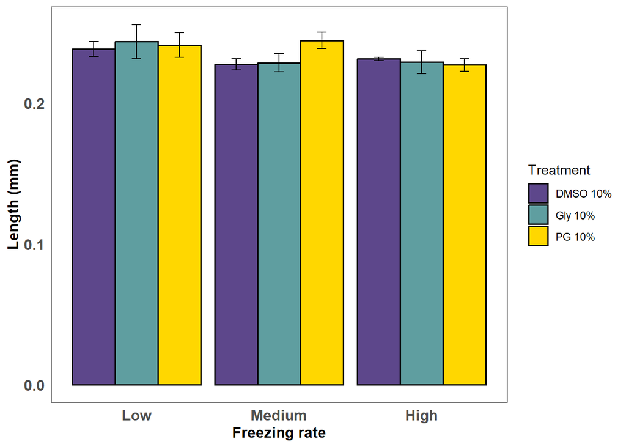

```r
Thawed5Aug_mean$Freezing_rate <- factor(Thawed5Aug_mean$Freezing_rate, levels = c("Low","Medium", "High"))

Thawed5Aug_mean  %>%
ggplot(aes(x= Freezing_rate, y= MeanLength, fill = Treatment)) +
  geom_bar(stat="identity", color="black",
           position=position_dodge(), linewidth = 0.6) +
 geom_errorbar(aes(ymin=MeanLength-se_l, ymax=MeanLength+se_l), width=.2, position=position_dodge(0.9)) +
Theme1 +
labs( y="Length (mm)", x="Freezing rate")   +
  scale_fill_viridis(discrete = TRUE) +
theme(strip.text.x = element_text(size = 12))  + scale_fill_manual(
    values = c("DMSO 10%" = "mediumpurple4", "Gly 10%" = "cadetblue","PG 10%" = "gold")
  )
```

```r
ggsave("E4_length.jpeg", width = 15, height = 7, units = "cm")
```

### Germling Area

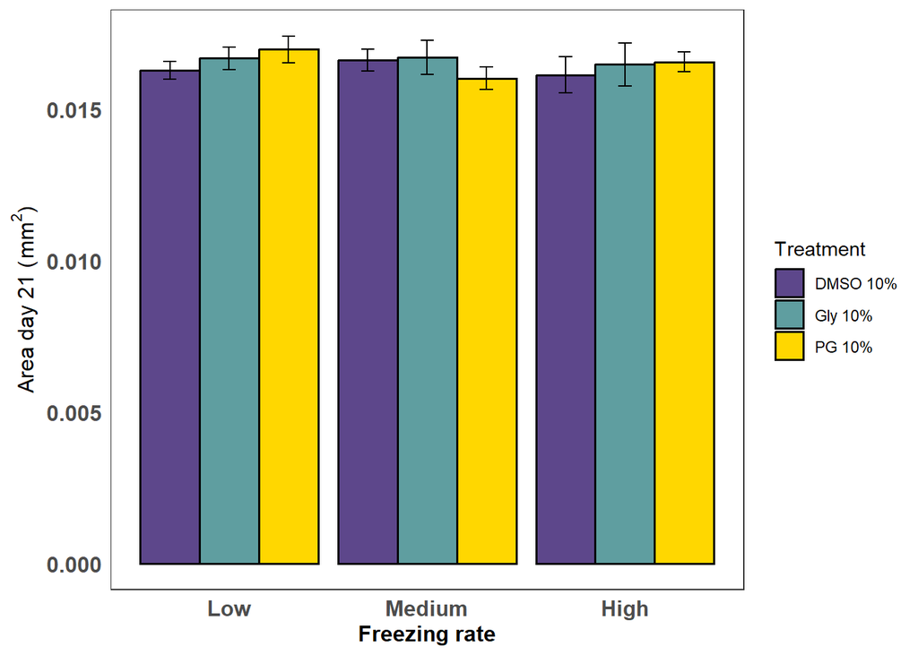

```r
Thawed5Aug_mean  %>%
ggplot(aes(x= Freezing_rate, y= MeanArea, fill = Treatment)) +
  geom_bar(stat="identity", color="black",
           position=position_dodge(), linewidth = 0.6) +
 geom_errorbar(aes(ymin=MeanArea-se_a, ymax=MeanArea+se_a), width=.2, position=position_dodge(0.9)) +
Theme1 +
labs( y=expression("Area day 21 ("~mm^2*")"), x="Freezing rate")   +
  scale_fill_viridis(discrete = TRUE) +
theme(strip.text.x = element_text(size = 12))  + scale_fill_manual(
    values = c("DMSO 10%" = "mediumpurple4", "Gly 10%" = "cadetblue","PG 10%" = "gold")
  )
```

```r
ggsave("E4_area.jpeg", width = 15, height = 7, units = "cm")
```

### Germling membrane detachment

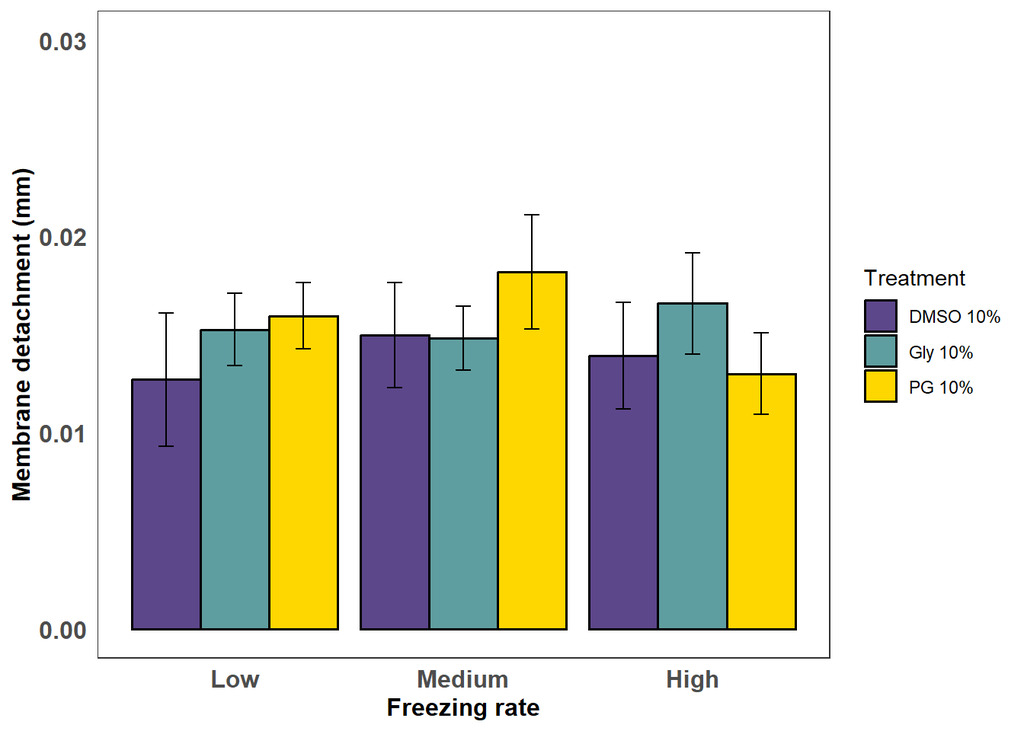

```r
Thawed5Aug_mean  %>%
ggplot(aes(x= Freezing_rate, y= MeanMembrane, fill = Treatment)) +
  geom_bar(stat="identity", color="black",
           position=position_dodge(), linewidth = 0.6) +
 geom_errorbar(aes(ymin=MeanMembrane-se_m, ymax=MeanMembrane+se_m), width=.2, position=position_dodge(0.9)) +
Theme1 +
labs( y="Membrane detachment (mm)", x="Freezing rate")   +
  scale_fill_viridis(discrete = TRUE) +
theme(strip.text.x = element_text(size = 12))  + scale_fill_manual(
    values = c("DMSO 10%" = "mediumpurple4", "Gly 10%" = "cadetblue","PG 10%" = "gold")
  ) + scale_y_continuous(limits = c(0, 0.03))
```

```r
ggsave("E4_membrane.jpeg", width = 15, height = 7, units = "cm")
```

### Germling cellular damage

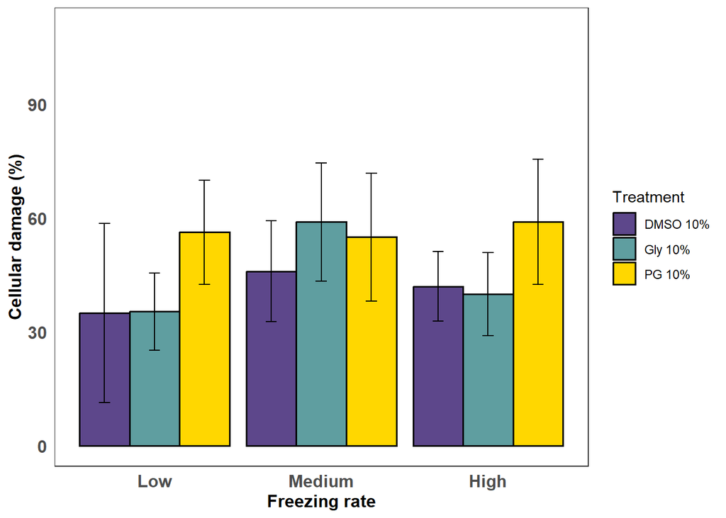

```r
Thawed5Aug_mean  %>%
ggplot(aes(x= Freezing_rate, y= MeanDamage, fill = Treatment)) +
  geom_bar(stat="identity", color="black",
           position=position_dodge(), linewidth = 0.6) +
 geom_errorbar(aes(ymin=MeanDamage-se_d, ymax=MeanDamage+se_d), width=.2, position=position_dodge(0.9)) +
Theme1 +
labs( y="Cellular damage (%)", x="Freezing rate")   +
  scale_fill_viridis(discrete = TRUE) +
theme(strip.text.x = element_text(size = 12)) + scale_fill_manual(
    values = c("DMSO 10%" = "mediumpurple4", "Gly 10%" = "cadetblue","PG 10%" = "gold")
  ) + scale_y_continuous(limits = c(0, 110))
```

```r
ggsave("E4_damage.jpeg", width = 15, height = 7, units = "cm")
```

## **5d)** Statistical analyses

### Length

```r
Thawed5Aug_female$Female <- as.factor(Thawed5Aug_female$Female)
```

```r
model <- lmer(Length ~ Treatment*Freezing_rate + (1|Female), data = Thawed5Aug_female)
summary(model)
```

```
## Linear mixed model fit by REML ['lmerMod']
## Formula: Length ~ Treatment * Freezing_rate + (1 | Female)
##    Data: Thawed5Aug_female
##
## REML criterion at convergence: -174.4
##
## Scaled residuals:
##      Min       1Q   Median       3Q      Max
## -3.07287 -0.54206  0.06214  0.57361  1.75637
##
## Random effects:
##  Groups   Name        Variance  Std.Dev.
##  Female   (Intercept) 1.685e-06 0.001298
##  Residual             2.280e-04 0.015101
## Number of obs: 43, groups:  Female, 6
##
## Fixed effects:
##                                       Estimate Std. Error t value
## (Intercept)                           0.231522   0.006778  34.158
## TreatmentGly 10%                     -0.002410   0.009550  -0.252
## TreatmentPG 10%                      -0.004420   0.009550  -0.463
## Freezing_rateLow                      0.007013   0.010134   0.692
## Freezing_rateMedium                  -0.003980   0.009550  -0.417
## TreatmentGly 10%:Freezing_rateLow     0.007523   0.013925   0.540
## TreatmentPG 10%:Freezing_rateLow      0.007228   0.014326   0.505
## TreatmentGly 10%:Freezing_rateMedium  0.003398   0.013511   0.252
## TreatmentPG 10%:Freezing_rateMedium   0.021430   0.013506   1.587
##
## Correlation of Fixed Effects:
##             (Intr) TrG10% TrPG10% Frzn_L Frzn_M TG10%:F_L TPG10%:F_L TG10%:F_M
## TrtmntGl10% -0.705
## TrtmntPG10% -0.705  0.500
## Frezng_rtLw -0.664  0.471  0.471
## Frzng_rtMdm -0.705  0.500  0.500   0.471
## TrtG10%:F_L  0.483 -0.686 -0.343  -0.728 -0.343
## TrPG10%:F_L  0.470 -0.333 -0.667  -0.707 -0.333  0.514
## TrtG10%:F_M  0.497 -0.707 -0.353  -0.333 -0.707  0.485     0.236
## TrPG10%:F_M  0.498 -0.354 -0.707  -0.333 -0.707  0.242     0.471      0.500
```

```r
car::Anova(model)
```

```
## Analysis of Deviance Table (Type II Wald chisquare tests)
##
## Response: Length
##                          Chisq Df Pr(>Chisq)
## Treatment               0.9537  2    0.62073
## Freezing_rate           4.6090  2    0.09981 .
## Treatment:Freezing_rate 3.5123  4    0.47601
## ---
## Signif. codes:  0 '***' 0.001 '**' 0.01 '*' 0.05 '.' 0.1 ' ' 1
```

Check model assumptions:

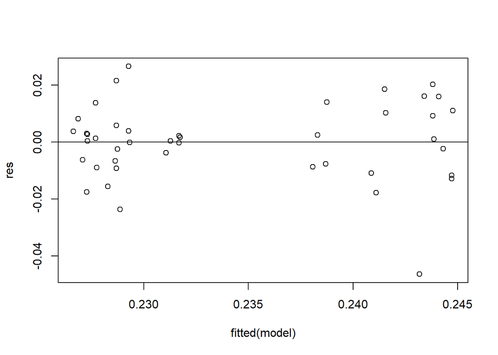

```r
res <- resid(model)

#produce residual vs. fitted plot
plot(fitted(model), res)

#add a horizontal line at 0
abline(0,0)
```

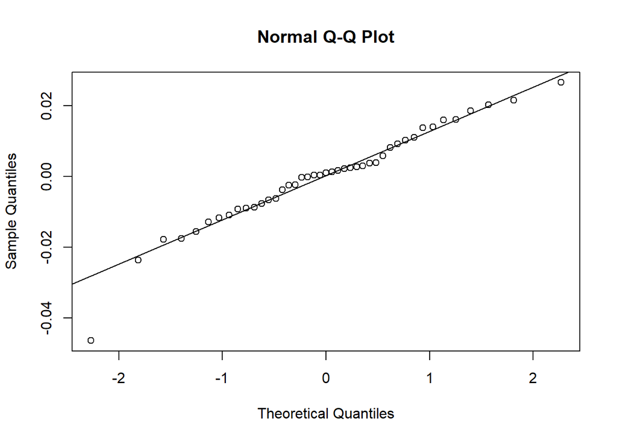

```r
#create Q-Q plot for residuals
qqnorm(res)

#add a straight diagonal line to the plot
qqline(res)
```

### Area

```r
model <- lmer(Area ~ Treatment*Freezing_rate + (1|Female), data = Thawed5Aug_female)
```

```
## boundary (singular) fit: see help('isSingular')
```

```r
summary(model)
```

```
## Linear mixed model fit by REML ['lmerMod']
## Formula: Area ~ Treatment * Freezing_rate + (1 | Female)
##    Data: Thawed5Aug_female
##
## REML criterion at convergence: -356.1
##
## Scaled residuals:
##     Min      1Q  Median      3Q     Max
## -2.3681 -0.4583 -0.1671  0.6533  1.9766
##
## Random effects:
##  Groups   Name        Variance  Std.Dev.
##  Female   (Intercept) 0.000e+00 0.000000
##  Residual             1.097e-06 0.001047
## Number of obs: 43, groups:  Female, 6
##
## Fixed effects:
##                                        Estimate Std. Error t value
## (Intercept)                           0.0161300  0.0004683  34.441
## TreatmentGly 10%                      0.0003500  0.0006623   0.528
## TreatmentPG 10%                       0.0004300  0.0006623   0.649
## Freezing_rateLow                      0.0001450  0.0007025   0.206
## Freezing_rateMedium                   0.0004900  0.0006623   0.740
## TreatmentGly 10%:Freezing_rateLow     0.0000550  0.0009655   0.057
## TreatmentPG 10%:Freezing_rateLow      0.0002700  0.0009935   0.272
## TreatmentGly 10%:Freezing_rateMedium -0.0002533  0.0009367  -0.270
## TreatmentPG 10%:Freezing_rateMedium  -0.0010267  0.0009367  -1.096
##
## Correlation of Fixed Effects:
##             (Intr) TrG10% TrPG10% Frzn_L Frzn_M TG10%:F_L TPG10%:F_L TG10%:F_M
## TrtmntGl10% -0.707
## TrtmntPG10% -0.707  0.500
## Frezng_rtLw -0.667  0.471  0.471
## Frzng_rtMdm -0.707  0.500  0.500   0.471
## TrtG10%:F_L  0.485 -0.686 -0.343  -0.728 -0.343
## TrPG10%:F_L  0.471 -0.333 -0.667  -0.707 -0.333  0.514
## TrtG10%:F_M  0.500 -0.707 -0.354  -0.333 -0.707  0.485     0.236
## TrPG10%:F_M  0.500 -0.354 -0.707  -0.333 -0.707  0.243     0.471      0.500
## optimizer (nloptwrap) convergence code: 0 (OK)
## boundary (singular) fit: see help('isSingular')
```

```r
car::Anova(model)
```

```
## Analysis of Deviance Table (Type II Wald chisquare tests)
##
## Response: Area
##                          Chisq Df Pr(>Chisq)
## Treatment               0.4767  2     0.7879
## Freezing_rate           0.4063  2     0.8162
## Treatment:Freezing_rate 2.1880  4     0.7012
```

Check model assumptions:

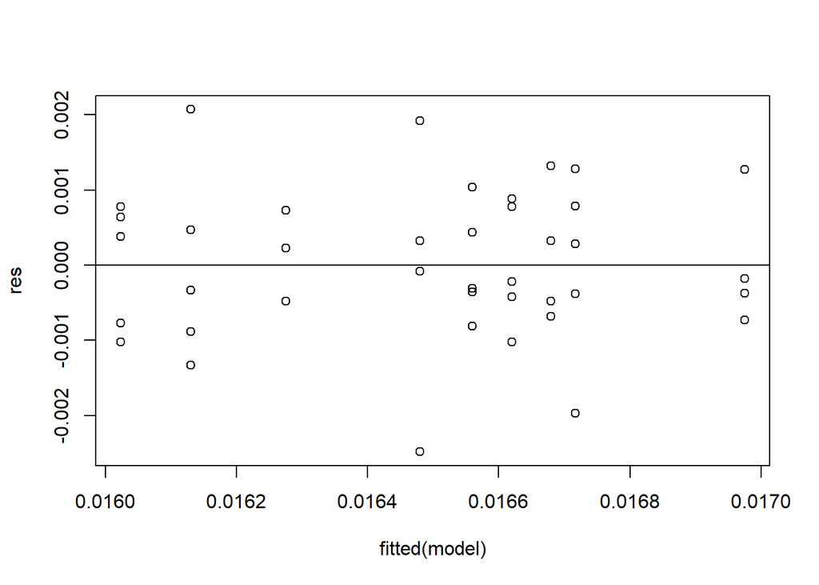

```r
res <- resid(model)

#produce residual vs. fitted plot
plot(fitted(model), res)

#add a horizontal line at 0
abline(0,0)
```

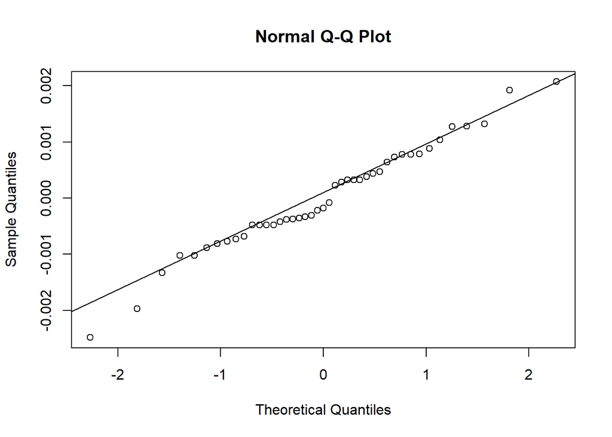

```r
#create Q-Q plot for residuals
qqnorm(res)

#add a straight diagonal line to the plot
qqline(res)
```

### Membrane detachment

```r
model <- lmer(Membrane_thickness ~ Treatment*Freezing_rate + (1|Female), data = Thawed5Aug_female)
summary(model)
```

```
## Linear mixed model fit by REML ['lmerMod']
## Formula: Membrane_thickness ~ Treatment * Freezing_rate + (1 | Female)
##    Data: Thawed5Aug_female
##
## REML criterion at convergence: -245.2
##
## Scaled residuals:
##     Min      1Q  Median      3Q     Max
## -1.8082 -0.5804 -0.1835  0.5676  1.9434
##
## Random effects:
##  Groups   Name        Variance  Std.Dev.
##  Female   (Intercept) 9.742e-08 0.0003121
##  Residual             2.849e-05 0.0053374
## Number of obs: 43, groups:  Female, 6
##
## Fixed effects:
##                                        Estimate Std. Error t value
## (Intercept)                           0.0139201  0.0023910   5.822
## TreatmentGly 10%                      0.0026800  0.0033757   0.794
## TreatmentPG 10%                      -0.0009100  0.0033757  -0.270
## Freezing_rateLow                     -0.0011914  0.0035811  -0.333
## Freezing_rateMedium                   0.0010600  0.0033757   0.314
## TreatmentGly 10%:Freezing_rateLow    -0.0001553  0.0049213  -0.032
## TreatmentPG 10%:Freezing_rateLow      0.0041433  0.0050635   0.818
## TreatmentGly 10%:Freezing_rateMedium -0.0028428  0.0047747  -0.595
## TreatmentPG 10%:Freezing_rateMedium   0.0041167  0.0047739   0.862
##
## Correlation of Fixed Effects:
##             (Intr) TrG10% TrPG10% Frzn_L Frzn_M TG10%:F_L TPG10%:F_L TG10%:F_M
## TrtmntGl10% -0.706
## TrtmntPG10% -0.706  0.500
## Frezng_rtLw -0.665  0.471  0.471
## Frzng_rtMdm -0.706  0.500  0.500   0.471
## TrtG10%:F_L  0.484 -0.686 -0.343  -0.728 -0.343
## TrPG10%:F_L  0.471 -0.333 -0.667  -0.707 -0.333  0.514
## TrtG10%:F_M  0.499 -0.707 -0.353  -0.333 -0.707  0.485     0.236
## TrPG10%:F_M  0.499 -0.354 -0.707  -0.333 -0.707  0.243     0.471      0.500
```

```r
car::Anova(model)
```

```
## Analysis of Deviance Table (Type II Wald chisquare tests)
##
## Response: Membrane_thickness
##                          Chisq Df Pr(>Chisq)
## Treatment               0.9427  2     0.6242
## Freezing_rate           0.6937  2     0.7069
## Treatment:Freezing_rate 2.3700  4     0.6681
```

Check model assumptions:

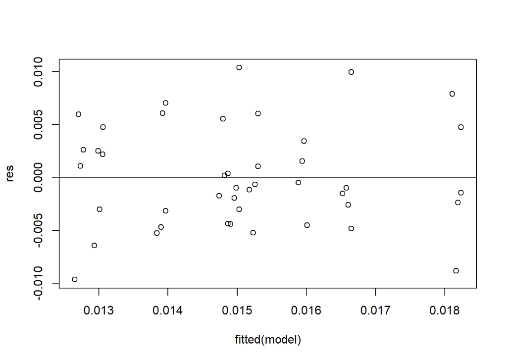

```r
res <- resid(model)

#produce residual vs. fitted plot
plot(fitted(model), res)

#add a horizontal line at 0
abline(0,0)
```

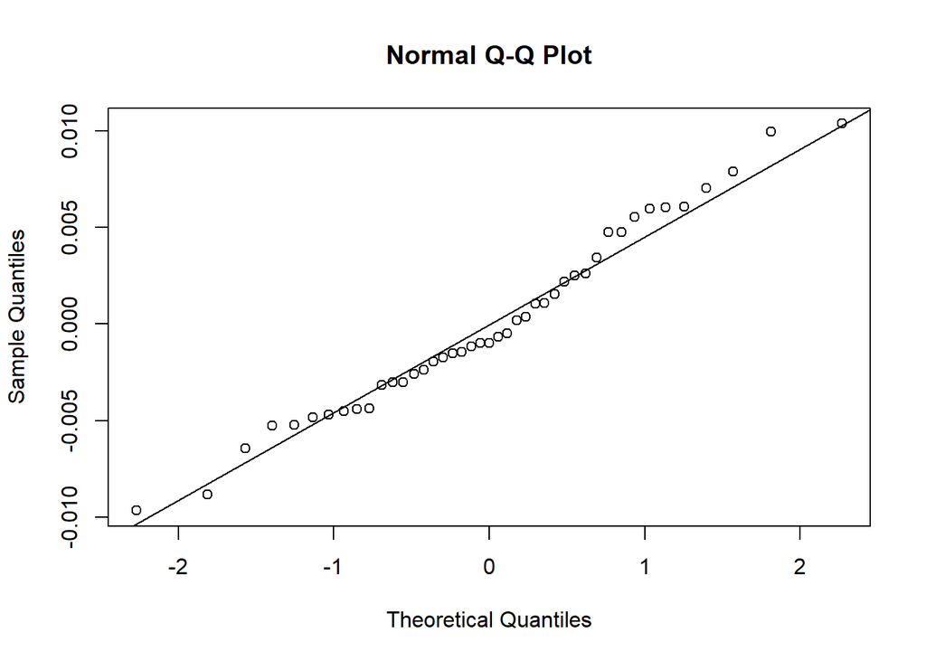

```r
#create Q-Q plot for residuals
qqnorm(res)

#add a straight diagonal line to the plot
qqline(res)
```

```r
model <- lmer(Cellular_damage ~ Treatment*Freezing_rate + (1|Female), data = Thawed5Aug_female)
summary(model)
```

```
## Linear mixed model fit by REML ['lmerMod']
## Formula: Cellular_damage ~ Treatment * Freezing_rate + (1 | Female)
##    Data: Thawed5Aug_female
##
## REML criterion at convergence: 342.8
##
## Scaled residuals:
##      Min       1Q   Median       3Q      Max
## -1.72615 -0.68239  0.07154  0.65851  1.73235
##
## Random effects:
##  Groups   Name        Variance Std.Dev.
##  Female   (Intercept) 209.9    14.49
##  Residual             805.3    28.38
## Number of obs: 43, groups:  Female, 6
##
## Fixed effects:
##                                      Estimate Std. Error t value
## (Intercept)                            40.391     14.201   2.844
## TreatmentGly 10%                       -2.000     17.948  -0.111
## TreatmentPG 10%                        17.000     17.948   0.947
## Freezing_rateLow                       -7.131     19.135  -0.373
## Freezing_rateMedium                     4.000     17.948   0.223
## TreatmentGly 10%:Freezing_rateLow       2.465     26.235   0.094
## TreatmentPG 10%:Freezing_rateLow        4.250     26.922   0.158
## TreatmentGly 10%:Freezing_rateMedium   16.517     25.588   0.645
## TreatmentPG 10%:Freezing_rateMedium    -8.000     25.383  -0.315
##
## Correlation of Fixed Effects:
##             (Intr) TrG10% TrPG10% Frzn_L Frzn_M TG10%:F_L TPG10%:F_L TG10%:F_M
## TrtmntGl10% -0.632
## TrtmntPG10% -0.632  0.500
## Frezng_rtLw -0.593  0.469  0.469
## Frzng_rtMdm -0.632  0.500  0.500   0.469
## TrtG10%:F_L  0.432 -0.684 -0.342  -0.729 -0.342
## TrPG10%:F_L  0.421 -0.333 -0.667  -0.703 -0.333  0.513
## TrtG10%:F_M  0.425 -0.701 -0.351  -0.331 -0.701  0.481     0.234
## TrPG10%:F_M  0.447 -0.354 -0.707  -0.332 -0.707  0.242     0.471      0.496
```

```r
car::Anova(model)
```

```
## Analysis of Deviance Table (Type II Wald chisquare tests)
##
## Response: Cellular_damage
##                          Chisq Df Pr(>Chisq)
## Treatment               2.1988  2     0.3331
## Freezing_rate           1.2099  2     0.5461
## Treatment:Freezing_rate 1.3170  4     0.8585
```

Check model assumptions:

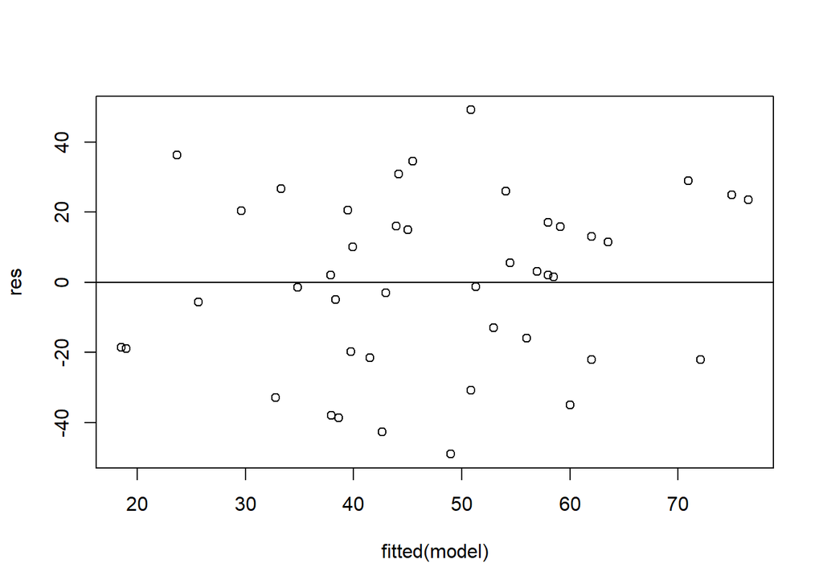

```r
res <- resid(model)

#produce residual vs. fitted plot
plot(fitted(model), res)

#add a horizontal line at 0
abline(0,0)
```

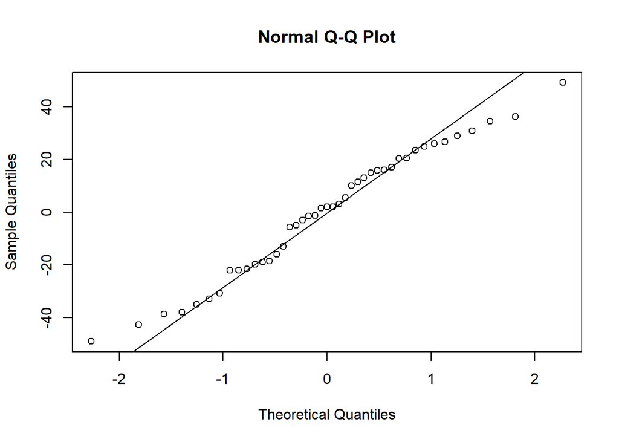

```r
#create Q-Q plot for residuals
qqnorm(res)

#add a straight diagonal line to the plot
qqline(res)
```

_______________________________

# **6.** Experiment 5: CPA and sugar toxicity on germlings

## **6a)** Import data

```r
Counts_toxSugar <- read.csv("Data_cryo/Germling_tox_19Aug.csv")
Lengths_toxSugar <- read.csv("Data_cryo/Germling_tox_19Aug_Lengths.csv")
```

## **6b)** Data structure and summary

### Germling counts

1. Check structure

```r
str(Counts_toxSugar)
```

```
## 'data.frame':    195 obs. of  14 variables:
##  $ Site           : chr  "South Cronulla" "South Cronulla" "South Cronulla" "South Cronulla" ...
##  $ DOB            : chr  "16/08/2024" "16/08/2024" "16/08/2024" "16/08/2024" ...
##  $ Date           : chr  "19-Aug" "19-Aug" "19-Aug" "19-Aug" ...
##  $ Age            : chr  "3-4 days" "3-4 days" "3-4 days" "3-4 days" ...
##  $ Number         : int  1 2 3 4 5 6 7 8 9 10 ...
##  $ Female         : int  1 1 1 1 1 1 1 1 1 1 ...
##  $ CPA            : chr  "DMSO" "DMSO" "DMSO" "DMSO" ...
##  $ Concentration  : int  10 10 10 5 5 5 10 10 10 5 ...
##  $ Add            : chr  "None" "Tre" "Suc" "None" ...
##  $ Treatment      : chr  "DMSO 10%" "DMSO 10% + Tre 0.1M" "DMSO 10% + Suc 0.1M" "DMSO 5%" ...
##  $ Equilibration  : int  20 20 20 20 20 20 20 20 20 20 ...
##  $ Day            : int  0 0 0 0 0 0 0 0 0 0 ...
##  $ Alive_germlings: int  72 56 52 70 55 79 58 76 67 72 ...
##  $ Starting_alive : int  133 92 171 136 84 130 120 118 134 151 ...
```

3. Calculate mean by treatment and day

```r
toxSugar_percent <- Counts_toxSugar %>%
  group_by (Treatment, Day, Female) %>%
  summarise(Percent_survival = ((Alive_germlings*100)/Starting_alive)) %>%
  filter(Percent_survival != "NaN")

percent_mean <- toxSugar_percent %>%
  group_by (Treatment, Day) %>%
  summarise(Count_mean = mean(Percent_survival), n = n(), sd = sd(Percent_survival), se = sd/sqrt(n))
```

### Germling length

1. Check structure

```r
str(Lengths_toxSugar)
```

```
## 'data.frame':    732 obs. of  19 variables:
##  $ Site         : chr  "South Cronulla" "South Cronulla" "South Cronulla" "South Cronulla" ...
##  $ DOB          : chr  "16/08/2024" "16/08/2024" "16/08/2024" "16/08/2024" ...
##  $ Date         : chr  "10-Sep" "27-Aug" "27-Aug" "10-Sep" ...
##  $ Age          : chr  "25 days" "11 days " "11 days " "25 days" ...
##  $ Day          : int  21 8 8 21 21 21 21 21 21 21 ...
##  $ Number       : int  58 32 46 64 64 64 65 61 65 65 ...
##  $ Female       : int  8 6 7 7 7 7 8 1 8 8 ...
##  $ CPA          : chr  "PG" "PG" "PG" "PC" ...
##  $ Concentration: int  5 10 5 NA NA NA NA NA NA NA ...
##  $ Add          : chr  "None" "Tre" "None" "None" ...
##  $ Treatment    : chr  "PG 5%" "PG 10% + Tre 0.1M" "PG 5%" "Control" ...
##  $ Equilibration: int  20 20 20 20 20 20 20 20 20 20 ...
##  $ Photo        : chr  "IMG_6413" "IMG_6065" "IMG_6070" "IMG_6265" ...
##  $ Replicate    : int  6 4 1 5 2 3 2 1 5 4 ...
##  $ Length_noriz : num  1.158 0.5 0.726 1.663 1.499 ...
##  $ Area         : num  0.224 0.099 0.099 0.338 0.335 0.334 0.315 0.308 0.301 0.289 ...
##  $ Shape        : chr  "Elongated" "Elongated" "Elongated" "Elongated" ...
##  $ Status       : chr  "Normal" "Normal" "Normal" "Normal" ...
##  $ Colour       : int  2 3 3 2 2 2 3 2 3 3 ...
```

2. Calculate mean value for each female

```r
Lengths_toxSugar$Day <- as.factor(Lengths_toxSugar$Day)
Lengths_Sugar <- Lengths_toxSugar %>%
group_by (Treatment, Day, Female) %>%
summarise(Length = mean(Length_noriz), Area = mean(Area))
```

3. Calculate mean by treatment and day

```r
LengthSugar_mean <- Lengths_Sugar  %>%
  group_by (Treatment,Day) %>%
  summarise(MeanLength = mean(Length),n = n(), sd_l = sd(Length), se_l = sd_l/sqrt(n), MeanArea = mean(Area),n = n(), sd_a = sd(Area), se_a = sd_a/sqrt(n))
```

## **6c)** Visualise patterns

### Germling counts

#### i. Survival plot

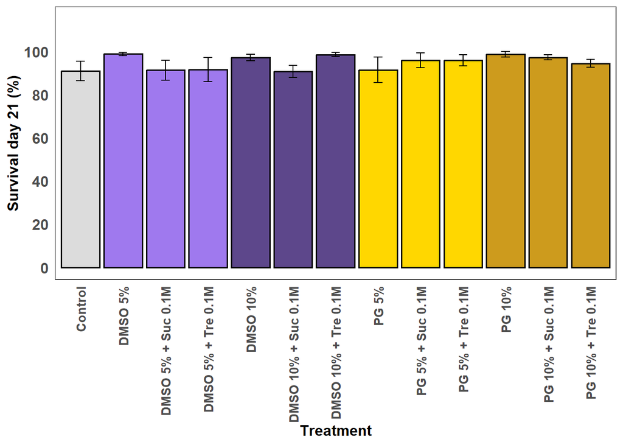

```r
percent_mean$Treatment <- factor(percent_mean$Treatment, levels = c("Control", "DMSO 5%", "DMSO 5% + Suc 0.1M", "DMSO 5% + Tre 0.1M", "DMSO 10%", "DMSO 10% + Suc 0.1M", "DMSO 10% + Tre 0.1M", "PG 5%", "PG 5% + Suc 0.1M", "PG 5% + Tre 0.1M", "PG 10%", "PG 10% + Suc 0.1M", "PG 10% + Tre 0.1M"))

percent_mean$Day <- as.factor(percent_mean$Day)
Count_plot6 <- percent_mean %>%
filter(Day == "21") %>%
ggplot(aes(x= Treatment, y= Count_mean, fill = Treatment)) +
  geom_bar(stat="identity", color="black",
           position=position_dodge(), linewidth = 0.6) +
 geom_errorbar(aes(ymin=Count_mean-se, ymax=Count_mean+se), width=.2, position=position_dodge(0.9)) +
Theme1 +
labs( y="Survival day 21 (%)", x="Treatment") +
theme(axis.text.x = element_text(angle = 90, vjust = 0.5, hjust=1, size = 10), legend.position="none") + scale_y_continuous(limits = c(0,115), breaks = c(seq(0,100, by = 20))) +
scale_fill_manual(
    values = c("Control"= "gainsboro", "DMSO 5%"= "mediumpurple2", "DMSO 5% + Suc 0.1M" = "mediumpurple2", "DMSO 5% + Tre 0.1M" = "mediumpurple2", "DMSO 10%" = "mediumpurple4", "DMSO 10% + Suc 0.1M" = "mediumpurple4", "DMSO 10% + Tre 0.1M" = "mediumpurple4", "PG 5%" = "gold", "PG 5% + Suc 0.1M" = "gold", "PG 5% + Tre 0.1M" = "gold", "PG 10%" = "goldenrod3", "PG 10% + Suc 0.1M" = "goldenrod3", "PG 10% + Tre 0.1M" = "goldenrod3"))+ theme(legend.position="none")



Count_plot6
```

```r
ggsave("E5_tox_surv.jpeg", width = 14, height = 10, units = "cm")
```

### Germling length

#### i. Length plot

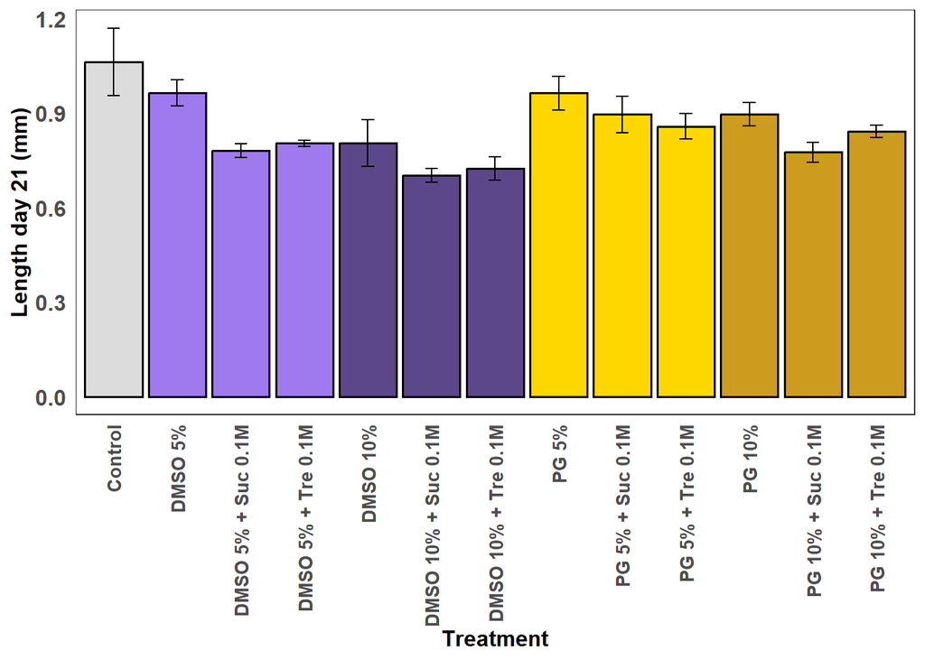

```r
LengthSugar_mean$Treatment <- factor(LengthSugar_mean$Treatment, levels = c("Control", "DMSO 5%", "DMSO 5% + Suc 0.1M", "DMSO 5% + Tre 0.1M", "DMSO 10%", "DMSO 10% + Suc 0.1M", "DMSO 10% + Tre 0.1M", "PG 5%", "PG 5% + Suc 0.1M", "PG 5% + Tre 0.1M", "PG 10%", "PG 10% + Suc 0.1M", "PG 10% + Tre 0.1M"))
plot6 <- LengthSugar_mean  %>%
  filter( Day == "21") %>%
ggplot(aes(x= Treatment, y= MeanLength, fill = Treatment)) +
  geom_bar(stat="identity", color="black",
           position=position_dodge(), linewidth = 0.6) +
 geom_errorbar(aes(ymin=MeanLength-se_l, ymax=MeanLength+se_l), width=.2, position=position_dodge(0.9)) +
Theme1 +
labs( y="Length day 21 (mm)", x="Treatment")   +
  scale_fill_viridis(discrete = TRUE) +
theme(strip.text.x = element_text(size = 12), axis.text.x = element_text(angle = 90, vjust = 0.5, hjust=1, size = 10), legend.position="none") +
scale_fill_manual(
    values = c("Control"= "gainsboro", "DMSO 5%"= "mediumpurple2", "DMSO 5% + Suc 0.1M" = "mediumpurple2", "DMSO 5% + Tre 0.1M" = "mediumpurple2", "DMSO 10%" = "mediumpurple4", "DMSO 10% + Suc 0.1M" = "mediumpurple4", "DMSO 10% + Tre 0.1M" = "mediumpurple4", "PG 5%" = "gold", "PG 5% + Suc 0.1M" = "gold", "PG 5% + Tre 0.1M" = "gold", "PG 10%" = "goldenrod3", "PG 10% + Suc 0.1M" = "goldenrod3", "PG 10% + Tre 0.1M" = "goldenrod3"))+ theme(legend.position="none")
plot6
```

```r
ggsave("E5_tox_length.jpeg", width = 14, height = 10, units = "cm")
```

#### ii. Area plot

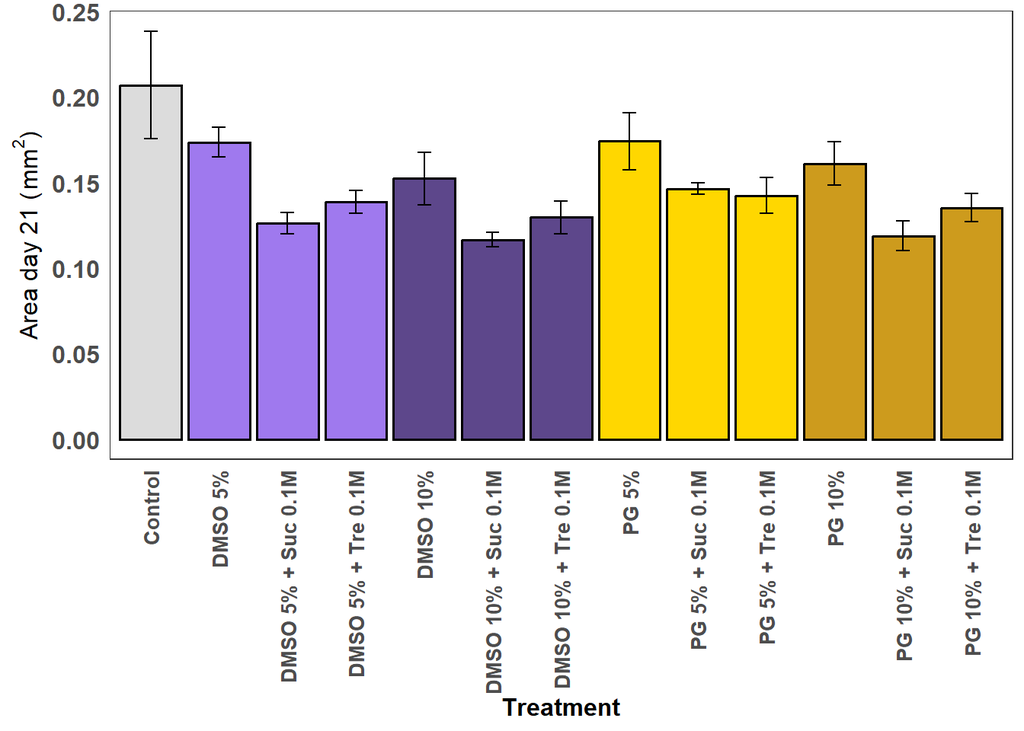

```r
plot6 <- LengthSugar_mean  %>%
  filter( Day == "21") %>%
ggplot(aes(x= Treatment, y= MeanArea, fill = Treatment)) +
  geom_bar(stat="identity", color="black",
           position=position_dodge(), linewidth = 0.6) +
 geom_errorbar(aes(ymin=MeanArea-se_a, ymax=MeanArea+se_a), width=.2, position=position_dodge(0.9)) +
Theme1 +
labs( y=expression("Area day 21 ("~mm^2*")"), x="Treatment")   +
  scale_fill_viridis(discrete = TRUE) +
theme(strip.text.x = element_text(size = 12), axis.text.x = element_text(angle = 90, vjust = 0.5, hjust=1, size=10), legend.position="none") +
scale_fill_manual(
    values = c("Control"= "gainsboro", "DMSO 5%"= "mediumpurple2", "DMSO 5% + Suc 0.1M" = "mediumpurple2", "DMSO 5% + Tre 0.1M" = "mediumpurple2", "DMSO 10%" = "mediumpurple4", "DMSO 10% + Suc 0.1M" = "mediumpurple4", "DMSO 10% + Tre 0.1M" = "mediumpurple4", "PG 5%" = "gold", "PG 5% + Suc 0.1M" = "gold", "PG 5% + Tre 0.1M" = "gold", "PG 10%" = "goldenrod3", "PG 10% + Suc 0.1M" = "goldenrod3", "PG 10% + Tre 0.1M" = "goldenrod3"))+ theme(legend.position="none")
plot6
```

```r
ggsave("E5_tox_area.jpeg", width = 14, height = 10, units = "cm")
```

## **6d)** Statistical analyses

### Germling counts

#### i. Survival

```r
 toxSugar_percent21 <- filter(toxSugar_percent, Day == "21")
model <- lmer(sqrt(Percent_survival) ~ Treatment + (1|Female), data = toxSugar_percent21)
```

```
## boundary (singular) fit: see help('isSingular')
```

```r
summary(model)
```

```
## Linear mixed model fit by REML ['lmerMod']
## Formula: sqrt(Percent_survival) ~ Treatment + (1 | Female)
##    Data: toxSugar_percent21
##
## REML criterion at convergence: 73.3
##
## Scaled residuals:
##     Min      1Q  Median      3Q     Max
## -3.1942 -0.2255  0.1652  0.5363  1.1825
##
## Random effects:
##  Groups   Name        Variance Std.Dev.
##  Female   (Intercept) 0.0000   0.0000
##  Residual             0.1604   0.4004
## Number of obs: 65, groups:  Female, 5
##
## Fixed effects:
##                               Estimate Std. Error t value
## (Intercept)                   9.526471   0.179083  53.196
## TreatmentDMSO 10%             0.327096   0.253262   1.292
## TreatmentDMSO 10% + Suc 0.1M -0.006636   0.253262  -0.026
## TreatmentDMSO 10% + Tre 0.1M  0.399234   0.253262   1.576
## TreatmentDMSO 5%              0.415417   0.253262   1.640
## TreatmentDMSO 5% + Suc 0.1M   0.014202   0.253262   0.056
## TreatmentDMSO 5% + Tre 0.1M   0.022725   0.253262   0.090
## TreatmentPG 10%               0.407395   0.253262   1.609
## TreatmentPG 10% + Suc 0.1M    0.334619   0.253262   1.321
## TreatmentPG 10% + Tre 0.1M    0.191003   0.253262   0.754
## TreatmentPG 5%                0.014200   0.253262   0.056
## TreatmentPG 5% + Suc 0.1M     0.257592   0.253262   1.017
## TreatmentPG 5% + Tre 0.1M     0.258765   0.253262   1.022
```

```
##
## Correlation matrix not shown by default, as p = 13 > 12.
## Use print(x, correlation=TRUE)  or
##     vcov(x)        if you need it
```

```
## optimizer (nloptwrap) convergence code: 0 (OK)
## boundary (singular) fit: see help('isSingular')
```

```r
car::Anova(model)
```

```
## Analysis of Deviance Table (Type II Wald chisquare tests)
##
## Response: sqrt(Percent_survival)
##            Chisq Df Pr(>Chisq)
## Treatment 11.017 12     0.5275
```

Check model assumptions:

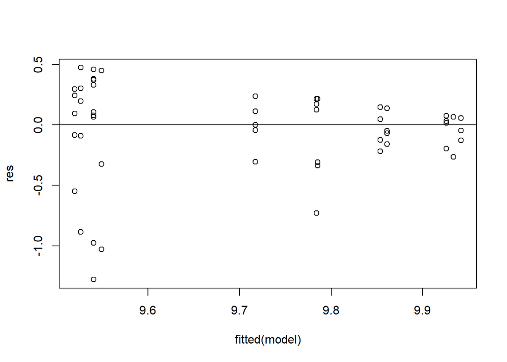

```r
res <- resid(model)

#produce residual vs. fitted plot
plot(fitted(model), res)

#add a horizontal line at 0
abline(0,0)
```

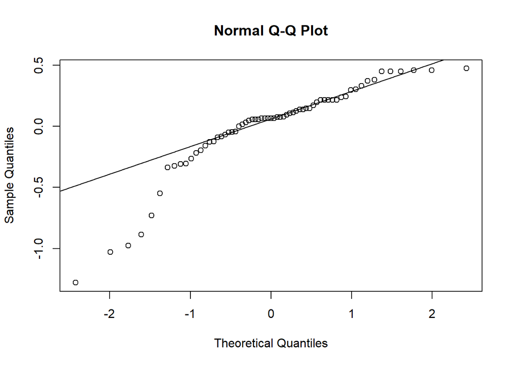

```r
#create Q-Q plot for residuals
qqnorm(res)

#add a straight diagonal line to the plot
qqline(res)
```

### Germling size

#### i. Length

```r
Lengths_Sugar21 <- filter(Lengths_Sugar, Day == "21")
model <- lmer(sqrt(Length) ~ Treatment + (1|Female), data = Lengths_Sugar21)
summary(model)
```

```
## Linear mixed model fit by REML ['lmerMod']
## Formula: sqrt(Length) ~ Treatment + (1 | Female)
##    Data: Lengths_Sugar21
##
## REML criterion at convergence: -133.9
##
## Scaled residuals:
##     Min      1Q  Median      3Q     Max
## -3.1869 -0.4014 -0.0423  0.5029  2.6390
##
## Random effects:
##  Groups   Name        Variance Std.Dev.
##  Female   (Intercept) 0.001147 0.03386
##  Residual             0.002140 0.04625
## Number of obs: 62, groups:  Female, 5
##
## Fixed effects:
##                              Estimate Std. Error t value
## (Intercept)                   1.02502    0.02564  39.983
## TreatmentDMSO 10%            -0.13169    0.02925  -4.502
## TreatmentDMSO 10% + Suc 0.1M -0.18733    0.02925  -6.404
## TreatmentDMSO 10% + Tre 0.1M -0.17502    0.02925  -5.983
## TreatmentDMSO 5%             -0.04392    0.02925  -1.501
## TreatmentDMSO 5% + Suc 0.1M  -0.14141    0.02925  -4.834
## TreatmentDMSO 5% + Tre 0.1M  -0.12820    0.02925  -4.382
## TreatmentPG 10%              -0.07940    0.02925  -2.714
## TreatmentPG 10% + Suc 0.1M   -0.14523    0.02925  -4.964
## TreatmentPG 10% + Tre 0.1M   -0.10762    0.02925  -3.679
## TreatmentPG 5%               -0.03729    0.03115  -1.197
## TreatmentPG 5% + Suc 0.1M    -0.09878    0.03409  -2.898
## TreatmentPG 5% + Tre 0.1M    -0.09971    0.02925  -3.409
```

```
##
## Correlation matrix not shown by default, as p = 13 > 12.
## Use print(x, correlation=TRUE)  or
##     vcov(x)        if you need it
```

```r
car::Anova(model)
```

```
## Analysis of Deviance Table (Type II Wald chisquare tests)
##
## Response: sqrt(Length)
##           Chisq Df Pr(>Chisq)
## Treatment 81.57 12  2.069e-12 ***
## ---
## Signif. codes:  0 '***' 0.001 '**' 0.01 '*' 0.05 '.' 0.1 ' ' 1
```

Contrasts:

```r
emmeans(model, specs = pairwise ~ Treatment, type = "response", adjust = "none")
```

```
## $emmeans
##  Treatment           response     SE   df lower.CL upper.CL
##  Control                1.051 0.0526 20.7    0.944    1.163
##  DMSO 10%               0.798 0.0458 20.7    0.706    0.896
##  DMSO 10% + Suc 0.1M    0.702 0.0430 20.7    0.615    0.794
##  DMSO 10% + Tre 0.1M    0.723 0.0436 20.7    0.635    0.816
##  DMSO 5%                0.963 0.0503 20.7    0.861    1.070
##  DMSO 5% + Suc 0.1M     0.781 0.0453 20.7    0.689    0.878
##  DMSO 5% + Tre 0.1M     0.804 0.0460 20.7    0.711    0.903
##  PG 10%                 0.894 0.0485 20.7    0.796    0.998
##  PG 10% + Suc 0.1M      0.774 0.0451 20.7    0.683    0.871
##  PG 10% + Tre 0.1M      0.842 0.0470 20.7    0.747    0.942
##  PG 5%                  0.976 0.0549 25.6    0.866    1.092
##  PG 5% + Suc 0.1M       0.858 0.0576 32.4    0.745    0.979
##  PG 5% + Tre 0.1M       0.856 0.0474 20.7    0.760    0.958
##
## Degrees-of-freedom method: kenward-roger
## Confidence level used: 0.95
## Intervals are back-transformed from the sqrt scale
##
## $contrasts
##  contrast                                      estimate     SE   df t.ratio
##  Control - DMSO 10%                             0.13169 0.0293 45.0   4.502
##  Control - (DMSO 10% + Suc 0.1M)                0.18733 0.0293 45.0   6.404
##  Control - (DMSO 10% + Tre 0.1M)                0.17502 0.0293 45.0   5.983
##  Control - DMSO 5%                              0.04392 0.0293 45.0   1.501
##  Control - (DMSO 5% + Suc 0.1M)                 0.14141 0.0293 45.0   4.834
##  Control - (DMSO 5% + Tre 0.1M)                 0.12820 0.0293 45.0   4.382
##  Control - PG 10%                               0.07940 0.0293 45.0   2.714
##  Control - (PG 10% + Suc 0.1M)                  0.14523 0.0293 45.0   4.964
##  Control - (PG 10% + Tre 0.1M)                  0.10762 0.0293 45.0   3.679
##  Control - PG 5%                                0.03729 0.0312 45.1   1.196
##  Control - (PG 5% + Suc 0.1M)                   0.09878 0.0341 45.2   2.894
##  Control - (PG 5% + Tre 0.1M)                   0.09971 0.0293 45.0   3.409
##  DMSO 10% - (DMSO 10% + Suc 0.1M)               0.05564 0.0293 45.0   1.902
##  DMSO 10% - (DMSO 10% + Tre 0.1M)               0.04333 0.0293 45.0   1.481
##  DMSO 10% - DMSO 5%                            -0.08777 0.0293 45.0  -3.000
##  DMSO 10% - (DMSO 5% + Suc 0.1M)                0.00972 0.0293 45.0   0.332
##  DMSO 10% - (DMSO 5% + Tre 0.1M)               -0.00349 0.0293 45.0  -0.119
##  DMSO 10% - PG 10%                             -0.05228 0.0293 45.0  -1.787
```

[output cut: 127 more lines]

```
##   0.5731
##   0.4911
##   0.2052
##   0.0012
##   0.1804
##   0.1267
##   0.0290
##   0.7968
##   0.7880
##   0.0943
##   0.0513
##   0.9784
##
## Note: contrasts are still on the sqrt scale
## Degrees-of-freedom method: kenward-roger
```

Check model assumptions:

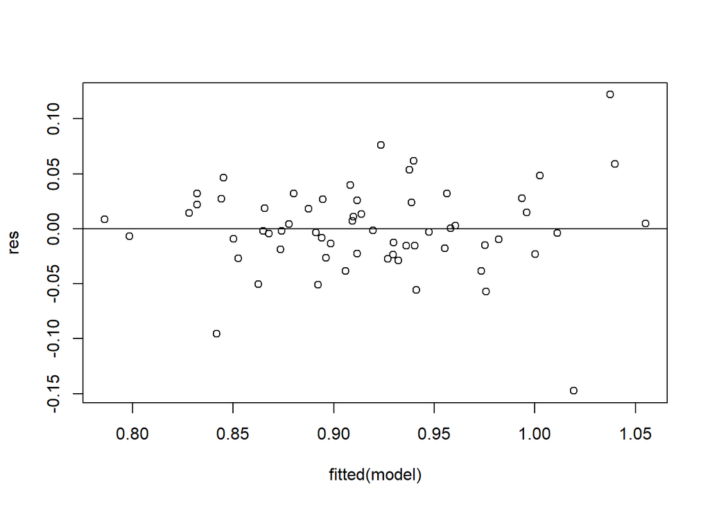

```r
res <- resid(model)

#produce residual vs. fitted plot
plot(fitted(model), res)

#add a horizontal line at 0
abline(0,0)
```

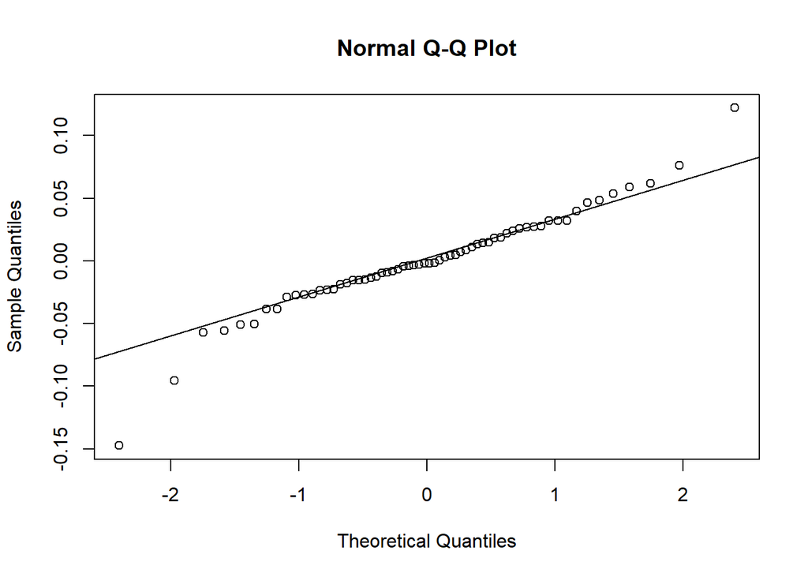

```r
#create Q-Q plot for residuals
qqnorm(res)

#add a straight diagonal line to the plot
qqline(res)
```

#### ii. Area

```r
Lengths_Sugar21 <- filter(Lengths_Sugar, Day == "21")
model <- lmer(sqrt(Area) ~ Treatment + (1|Female), data = Lengths_Sugar21)
summary(model)
```

```
## Linear mixed model fit by REML ['lmerMod']
## Formula: sqrt(Area) ~ Treatment + (1 | Female)
##    Data: Lengths_Sugar21
##
## REML criterion at convergence: -179.9
##
## Scaled residuals:
##     Min      1Q  Median      3Q     Max
## -3.7458 -0.3767  0.0828  0.4996  2.3108
##
## Random effects:
##  Groups   Name        Variance  Std.Dev.
##  Female   (Intercept) 0.0004852 0.02203
##  Residual             0.0008306 0.02882
## Number of obs: 62, groups:  Female, 5
##
## Fixed effects:
##                              Estimate Std. Error t value
## (Intercept)                   0.44933    0.01622  27.699
## TreatmentDMSO 10%            -0.06110    0.01823  -3.352
## TreatmentDMSO 10% + Suc 0.1M -0.10800    0.01823  -5.925
## TreatmentDMSO 10% + Tre 0.1M -0.09007    0.01823  -4.941
## TreatmentDMSO 5%             -0.03317    0.01823  -1.820
## TreatmentDMSO 5% + Suc 0.1M  -0.09434    0.01823  -5.176
## TreatmentDMSO 5% + Tre 0.1M  -0.07725    0.01823  -4.238
## TreatmentPG 10%              -0.04919    0.01823  -2.699
## TreatmentPG 10% + Suc 0.1M   -0.10565    0.01823  -5.796
## TreatmentPG 10% + Tre 0.1M   -0.08229    0.01823  -4.515
## TreatmentPG 5%               -0.02932    0.01941  -1.510
## TreatmentPG 5% + Suc 0.1M    -0.07884    0.02124  -3.712
## TreatmentPG 5% + Tre 0.1M    -0.07295    0.01823  -4.002
```

```
##
## Correlation matrix not shown by default, as p = 13 > 12.
## Use print(x, correlation=TRUE)  or
##     vcov(x)        if you need it
```

```r
car::Anova(model)
```

```
## Analysis of Deviance Table (Type II Wald chisquare tests)
##
## Response: sqrt(Area)
##           Chisq Df Pr(>Chisq)
## Treatment  72.2 12  1.239e-10 ***
## ---
## Signif. codes:  0 '***' 0.001 '**' 0.01 '*' 0.05 '.' 0.1 ' ' 1
```

Contrasts:

```r
emmeans(model, specs = pairwise ~ Treatment, type = "response", adjust = "none")
```

```
## $emmeans
##  Treatment           response     SE   df lower.CL upper.CL
##  Control                0.202 0.0146 19.4   0.1726    0.234
##  DMSO 10%               0.151 0.0126 19.4   0.1255    0.178
##  DMSO 10% + Suc 0.1M    0.117 0.0111 19.4   0.0945    0.141
##  DMSO 10% + Tre 0.1M    0.129 0.0117 19.4   0.1059    0.155
##  DMSO 5%                0.173 0.0135 19.4   0.1461    0.203
##  DMSO 5% + Suc 0.1M     0.126 0.0115 19.4   0.1031    0.151
##  DMSO 5% + Tre 0.1M     0.138 0.0121 19.4   0.1144    0.165
##  PG 10%                 0.160 0.0130 19.4   0.1341    0.188
##  PG 10% + Suc 0.1M      0.118 0.0112 19.4   0.0960    0.143
##  PG 10% + Tre 0.1M      0.135 0.0119 19.4   0.1110    0.161
##  PG 5%                  0.176 0.0147 24.0   0.1473    0.208
##  PG 5% + Suc 0.1M       0.137 0.0145 30.8   0.1093    0.168
##  PG 5% + Tre 0.1M       0.142 0.0122 19.4   0.1173    0.168
##
## Degrees-of-freedom method: kenward-roger
## Confidence level used: 0.95
## Intervals are back-transformed from the sqrt scale
##
## $contrasts
##  contrast                                      estimate     SE   df t.ratio
##  Control - DMSO 10%                             0.06110 0.0182 45.0   3.352
##  Control - (DMSO 10% + Suc 0.1M)                0.10800 0.0182 45.0   5.925
##  Control - (DMSO 10% + Tre 0.1M)                0.09007 0.0182 45.0   4.941
##  Control - DMSO 5%                              0.03317 0.0182 45.0   1.820
##  Control - (DMSO 5% + Suc 0.1M)                 0.09434 0.0182 45.0   5.176
##  Control - (DMSO 5% + Tre 0.1M)                 0.07725 0.0182 45.0   4.238
##  Control - PG 10%                               0.04919 0.0182 45.0   2.699
##  Control - (PG 10% + Suc 0.1M)                  0.10565 0.0182 45.0   5.796
##  Control - (PG 10% + Tre 0.1M)                  0.08229 0.0182 45.0   4.515
##  Control - PG 5%                                0.02932 0.0194 45.1   1.509
##  Control - (PG 5% + Suc 0.1M)                   0.07884 0.0213 45.2   3.706
##  Control - (PG 5% + Tre 0.1M)                   0.07295 0.0182 45.0   4.002
##  DMSO 10% - (DMSO 10% + Suc 0.1M)               0.04690 0.0182 45.0   2.573
##  DMSO 10% - (DMSO 10% + Tre 0.1M)               0.02897 0.0182 45.0   1.589
##  DMSO 10% - DMSO 5%                            -0.02793 0.0182 45.0  -1.532
##  DMSO 10% - (DMSO 5% + Suc 0.1M)                0.03324 0.0182 45.0   1.824
##  DMSO 10% - (DMSO 5% + Tre 0.1M)                0.01615 0.0182 45.0   0.886
##  DMSO 10% - PG 10%                             -0.01191 0.0182 45.0  -0.653
```

[output cut: 127 more lines]

```
##   0.1702
##   0.1992
##   0.2066
##   0.0003
##   0.2139
##   0.0795
##   0.0091
##   0.8717
##   0.6106
##   0.0323
##   0.0296
##   0.7830
##
## Note: contrasts are still on the sqrt scale
## Degrees-of-freedom method: kenward-roger
```

Check model assumptions:

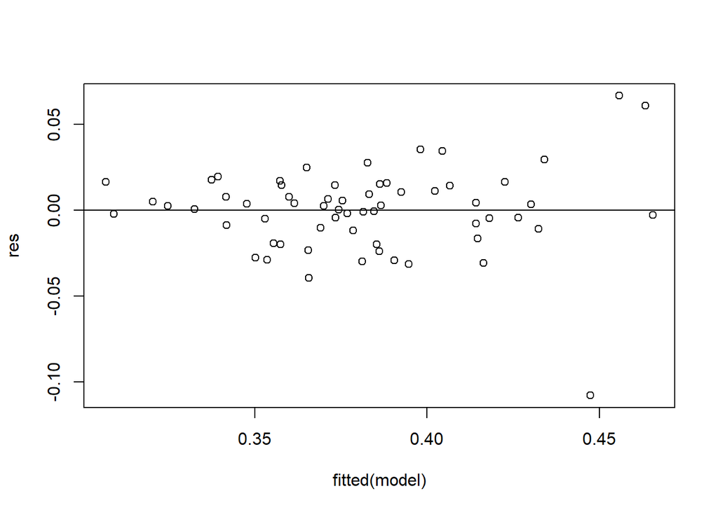

```r
res <- resid(model)

#produce residual vs. fitted plot
plot(fitted(model), res)

#add a horizontal line at 0
abline(0,0)
```

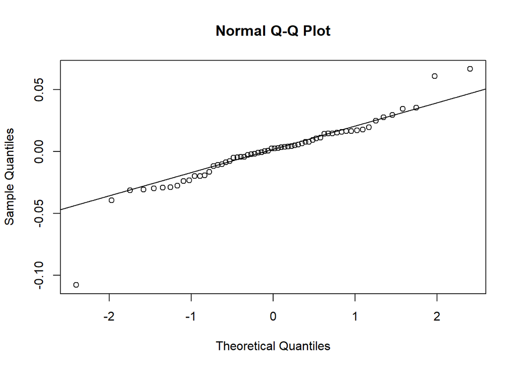

```r
#create Q-Q plot for residuals
qqnorm(res)

#add a straight diagonal line to the plot
qqline(res)
```

# **7.** Experiment 6: Effect of sugar addition on germlings viability after thawing

## **7a)** Import data

```r
Thawed9sep <- read.csv("Data_cryo/Germling_thawed_9sep.csv")
```

## **7b)** Data structure and summary

1. Check structure

```r
str(Thawed9sep)
```

```
## 'data.frame':    214 obs. of  20 variables:
##  $ Age                     : chr  "3 days " "3 days " "3 days " "3 days " ...
##  $ Method                  : chr  "Cryovial" "Cryovial" "Cryovial" "Cryovial" ...
##  $ Number                  : int  1 1 1 2 3 3 3 3 4 5 ...
##  $ Female                  : int  4 4 4 7 7 7 7 7 4 4 ...
##  $ CPA                     : chr  "PG" "PG" "PG" "FSW" ...
##  $ Concentration           : int  5 5 5 NA 10 10 10 10 10 5 ...
##  $ Add                     : chr  "Suc" "Suc" "Suc" "" ...
##  $ Treatment               : chr  "PG 5% + Suc 0.1M" "PG 5% + Suc 0.1M" "PG 5% + Suc 0.1M" "FSW" ...
##  $ Equilibration           : int  15 15 15 15 15 15 15 15 15 15 ...
##  $ Site                    : chr  "South Cronulla" "South Cronulla" "South Cronulla" "South Cronulla" ...
##  $ Date                    : chr  "9/09/2024" "9/09/2024" "9/09/2024" "9/09/2024" ...
##  $ Folder                  : chr  "Cryovials_thawed_9sep" "Cryovials_thawed_9sep" "Cryovials_thawed_9sep" "Cryovials_thawed_9sep" ...
##  $ Photo                   : chr  "D3_1_.jpg" "D3_1_.jpg" "D3_1_1.jpg" "D3_2_.jpg" ...
##  $ Replicate               : int  1 2 3 1 1 2 3 4 1 1 ...
##  $ Length                  : num  0.248 0.238 0.237 0.25 0.212 0.252 0.209 0.201 0.268 0.264 ...
##  $ Area                    : num  0.015 0.018 0.017 0.014 0.014 0.016 0.015 0.013 0.014 0.017 ...
##  $ Colour                  : int  1 1 1 2 2 2 2 2 2 2 ...
##  $ Membrane_thickness      : num  0.026 0.029 0.018 0.019 0.017 0.016 0.017 0.012 0.018 0.015 ...
##  $ Cellular_damage         : chr  "No" "No" "Yes" "Yes" ...
##  $ Visual_cellular_division: chr  "" "" "" "" ...
```

2. Calculate mean value for each female

```r
Thawed9sep_female <- Thawed9sep %>%
group_by (Treatment, Method,Female) %>%
summarise(Length = mean(Length), Area = mean(Area), Colour = mean(Colour), Membrane_thickness = mean(Membrane_thickness),
    Cellular_damage = sum(Cellular_damage == "Yes", na.rm = TRUE) * 100 / n())
```

3. Calculate mean by treatment and freezing method

```r
Thawed9sep_mean <- Thawed9sep_female  %>%
  group_by (Treatment, Method) %>%
  summarise(MeanLength = mean(Length),n = n(), sd_l = sd(Length), se_l = sd_l/sqrt(n), MeanArea = mean(Area),n = n(), sd_a = sd(Area), se_a = sd_a/sqrt(n), MeanColour = mean(Colour),n = n(), sd_c = sd(Colour), se_c = sd_c/sqrt(n), MeanMembrane = mean(Membrane_thickness),n = n(), sd_m = sd(Membrane_thickness), se_m = sd_m/sqrt(n), MeanDamage = mean(Cellular_damage),n = n(), sd_d = sd(Cellular_damage), se_d = sd_d/sqrt(n))
```

## **7c)** Visualise data

### Germling length

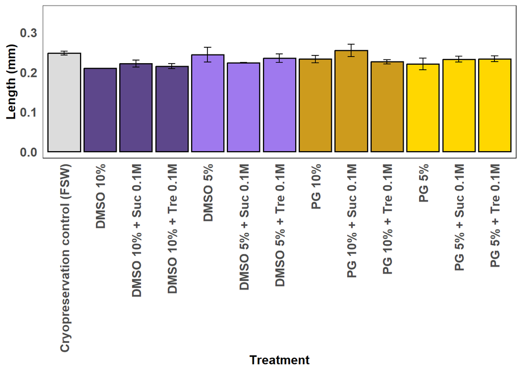

```r
Thawed9sep_mean$Treatment <- factor(Thawed9sep_mean$Treatment, levels = c("FSW", "DMSO 5%", "DMSO 5% + Suc 0.1M", "DMSO 5% + Tre 0.1M", "DMSO 10%", "DMSO 10% + Suc 0.1M", "DMSO 10% + Tre 0.1M", "PG 5%", "PG 5% + Suc 0.1M", "PG 5% + Tre 0.1M", "PG 10%", "PG 10% + Suc 0.1M", "PG 10% + Tre 0.1M"))
Thawed9sep_mean <- Thawed9sep_mean %>%
  mutate(Treatment = if_else(
    Treatment == "FSW",
    "Cryopreservation control (FSW)",
    Treatment
  ))


Thawed9sep_mean  %>%
filter(Method == "Cryovial") %>%
ggplot(aes(x= Treatment, y= MeanLength, fill = Treatment)) +
  geom_bar(stat="identity", color="black",
           position=position_dodge(), linewidth = 0.6) +
 geom_errorbar(aes(ymin=MeanLength-se_l, ymax=MeanLength+se_l), width=.2, position=position_dodge(0.9)) +
Theme1 +
labs( y="Length (mm)", x="Treatment")   +
theme(strip.text.x = element_text(size = 12))  +
theme(axis.text.x = element_text(angle = 90, vjust = 0.5, hjust=1)) + scale_y_continuous(limits = c(0,0.35)) +
scale_fill_manual(
    values = c("Cryopreservation control (FSW)"= "gainsboro", "DMSO 5%"= "mediumpurple2", "DMSO 5% + Suc 0.1M" = "mediumpurple2", "DMSO 5% + Tre 0.1M" = "mediumpurple2", "DMSO 10%" = "mediumpurple4", "DMSO 10% + Suc 0.1M" = "mediumpurple4", "DMSO 10% + Tre 0.1M" = "mediumpurple4", "PG 5%" = "gold", "PG 5% + Suc 0.1M" = "gold", "PG 5% + Tre 0.1M" = "gold", "PG 10%" = "goldenrod3", "PG 10% + Suc 0.1M" = "goldenrod3", "PG 10% + Tre 0.1M" = "goldenrod3"))+ theme(legend.position="none")
```

```r
ggsave("E7_length_cv.jpeg", width = 13.5, height = 12, units = "cm")
```

### Germling Area

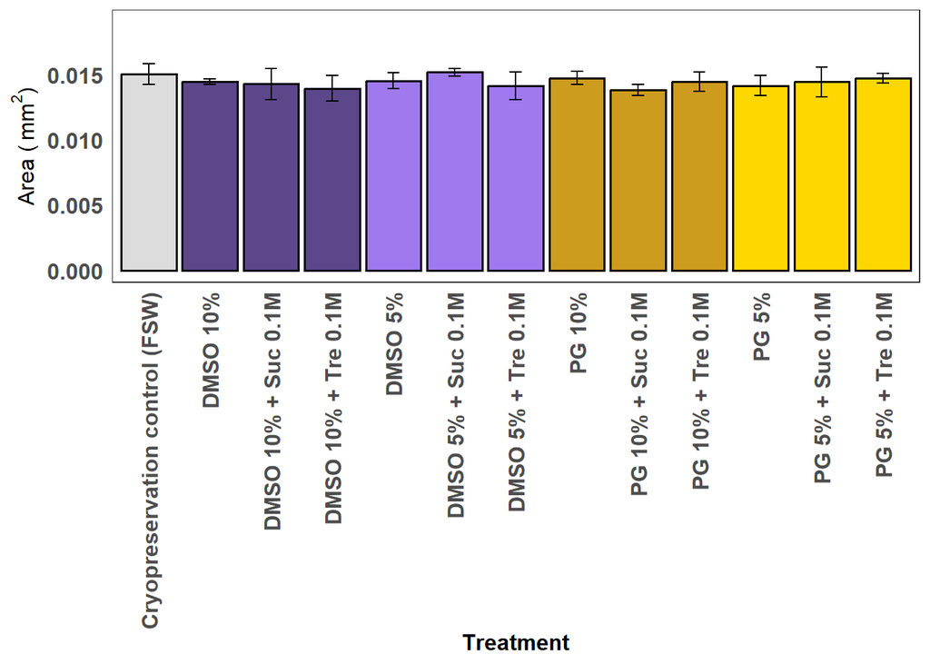

```r
Thawed9sep_mean  %>%
  filter(Method == "Cryovial") %>%
ggplot(aes(x= Treatment, y= MeanArea, fill = Treatment)) +
  geom_bar(stat="identity", color="black",
           position=position_dodge(), linewidth = 0.6) +
 geom_errorbar(aes(ymin=MeanArea-se_a, ymax=MeanArea+se_a), width=.2, position=position_dodge(0.9)) +
Theme1 +
labs( y=expression("Area ("~mm^2*")"), x="Treatment")   +
theme(strip.text.x = element_text(size = 12))   +
theme(axis.text.x = element_text(angle = 90, vjust = 0.5, hjust=1)) + scale_y_continuous(limits = c(0,0.019))+
scale_fill_manual(
    values = c("Cryopreservation control (FSW)"= "gainsboro", "DMSO 5%"= "mediumpurple2", "DMSO 5% + Suc 0.1M" = "mediumpurple2", "DMSO 5% + Tre 0.1M" = "mediumpurple2", "DMSO 10%" = "mediumpurple4", "DMSO 10% + Suc 0.1M" = "mediumpurple4", "DMSO 10% + Tre 0.1M" = "mediumpurple4", "PG 5%" = "gold", "PG 5% + Suc 0.1M" = "gold", "PG 5% + Tre 0.1M" = "gold", "PG 10%" = "goldenrod3", "PG 10% + Suc 0.1M" = "goldenrod3", "PG 10% + Tre 0.1M" = "goldenrod3"))+ theme(legend.position="none")
```

```r
ggsave("E7_area.jpeg", width = 13.5, height = 12, units = "cm")
```

### Germling membrane detachment

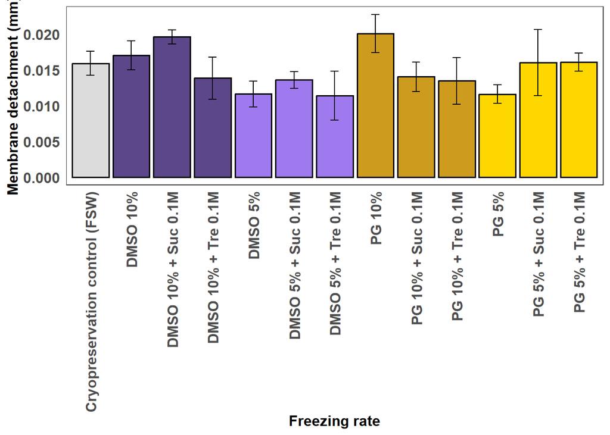

```r
Thawed9sep_mean  %>%
  filter(Method == "Cryovial") %>%
ggplot(aes(x= Treatment, y= MeanMembrane, fill = Treatment)) +
  geom_bar(stat="identity", color="black",
           position=position_dodge(), linewidth = 0.6) +
 geom_errorbar(aes(ymin=MeanMembrane-se_m, ymax=MeanMembrane+se_m), width=.2, position=position_dodge(0.9)) +
Theme1 +
labs( y="Membrane detachment (mm)", x="Freezing rate")   +
  scale_fill_viridis(discrete = TRUE) +
theme(strip.text.x = element_text(size = 12))  +
theme(axis.text.x = element_text(angle = 90, vjust = 0.5, hjust=1))+
scale_fill_manual(
    values = c("Cryopreservation control (FSW)"= "gainsboro", "DMSO 5%"= "mediumpurple2", "DMSO 5% + Suc 0.1M" = "mediumpurple2", "DMSO 5% + Tre 0.1M" = "mediumpurple2", "DMSO 10%" = "mediumpurple4", "DMSO 10% + Suc 0.1M" = "mediumpurple4", "DMSO 10% + Tre 0.1M" = "mediumpurple4", "PG 5%" = "gold", "PG 5% + Suc 0.1M" = "gold", "PG 5% + Tre 0.1M" = "gold", "PG 10%" = "goldenrod3", "PG 10% + Suc 0.1M" = "goldenrod3", "PG 10% + Tre 0.1M" = "goldenrod3"))+ theme(legend.position="none")
```

```r
ggsave("E7_membrane.jpeg", width = 14.5, height = 12.4, units = "cm")
```

### Germling cellular damage

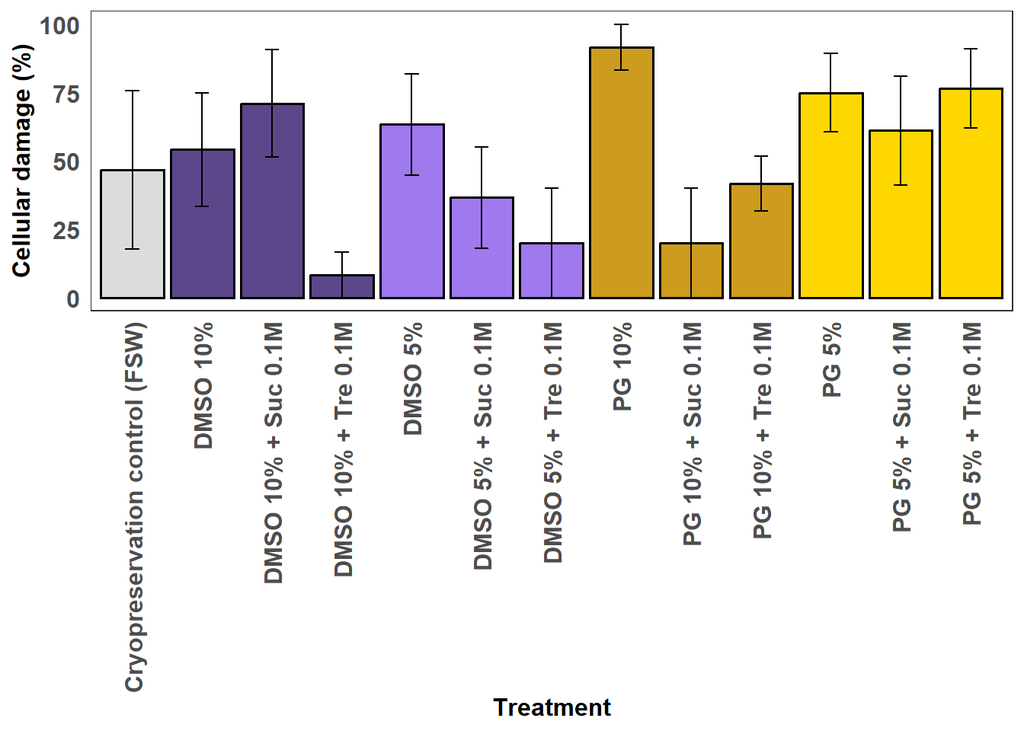

```r
Thawed9sep_mean  %>%
filter(Method == "Cryovial") %>%
ggplot(aes(x= Treatment, y= MeanDamage, fill = Treatment)) +
  geom_bar(stat="identity", color="black",
           position=position_dodge(), linewidth = 0.6) +
 geom_errorbar(aes(ymin=MeanDamage-se_d, ymax=MeanDamage+se_d), width=.2, position=position_dodge(0.9)) +
Theme1 +
labs( y="Cellular damage (%)", x="Treatment")   +
  scale_fill_viridis(discrete = TRUE) +
theme(strip.text.x = element_text(size = 12))  +
theme(axis.text.x = element_text(angle = 90, vjust = 0.5, hjust=1)) +
scale_fill_manual(
    values = c("Cryopreservation control (FSW)"= "gainsboro", "DMSO 5%"= "mediumpurple2", "DMSO 5% + Suc 0.1M" = "mediumpurple2", "DMSO 5% + Tre 0.1M" = "mediumpurple2", "DMSO 10%" = "mediumpurple4", "DMSO 10% + Suc 0.1M" = "mediumpurple4", "DMSO 10% + Tre 0.1M" = "mediumpurple4", "PG 5%" = "gold", "PG 5% + Suc 0.1M" = "gold", "PG 5% + Tre 0.1M" = "gold", "PG 10%" = "goldenrod3", "PG 10% + Suc 0.1M" = "goldenrod3", "PG 10% + Tre 0.1M" = "goldenrod3"))+ theme(legend.position="none")
```

```r
ggsave("E7_damage.jpeg", width = 13.5, height = 12, units = "cm")
```

## **7d)** Statistical analyses

### Length

```r
Thawed9sep_female$Female <- as.factor(Thawed9sep_female$Female)
Thawed9sep_CV <- filter(Thawed9sep_female, Method == "Cryovial")
```

```r
model <- lmer(Length ~ Treatment + (1|Female), data = Thawed9sep_CV)
summary(model)
```

```
## Linear mixed model fit by REML ['lmerMod']
## Formula: Length ~ Treatment + (1 | Female)
##    Data: Thawed9sep_CV
##
## REML criterion at convergence: -117.5
##
## Scaled residuals:
##     Min      1Q  Median      3Q     Max
## -1.7844 -0.5543 -0.0170  0.5549  2.0716
##
## Random effects:
##  Groups   Name        Variance  Std.Dev.
##  Female   (Intercept) 1.606e-06 0.001267
##  Residual             3.043e-04 0.017444
## Number of obs: 38, groups:  Female, 3
##
## Fixed effects:
##                              Estimate Std. Error t value
## (Intercept)                  0.209141   0.012366  16.912
## TreatmentDMSO 10% + Suc 0.1M 0.012104   0.015932   0.760
## TreatmentDMSO 10% + Tre 0.1M 0.005526   0.015932   0.347
## TreatmentDMSO 5%             0.034443   0.015932   2.162
## TreatmentDMSO 5% + Suc 0.1M  0.014193   0.015932   0.891
## TreatmentDMSO 5% + Tre 0.1M  0.025559   0.015932   1.604
## TreatmentFSW                 0.038359   0.015932   2.408
## TreatmentPG 10%              0.023471   0.015932   1.473
## TreatmentPG 10% + Suc 0.1M   0.045326   0.015932   2.845
## TreatmentPG 10% + Tre 0.1M   0.016593   0.015932   1.041
## TreatmentPG 5%               0.011126   0.015932   0.698
## TreatmentPG 5% + Suc 0.1M    0.023226   0.015932   1.458
## TreatmentPG 5% + Tre 0.1M    0.023876   0.015932   1.499
```

```
##
## Correlation matrix not shown by default, as p = 13 > 12.
## Use print(x, correlation=TRUE)  or
##     vcov(x)        if you need it
```

```r
car::Anova(model)
```

```
## Analysis of Deviance Table (Type II Wald chisquare tests)
##
## Response: Length
##            Chisq Df Pr(>Chisq)
## Treatment 18.579 12    0.09919 .
## ---
## Signif. codes:  0 '***' 0.001 '**' 0.01 '*' 0.05 '.' 0.1 ' ' 1
```

Check model assumptions:

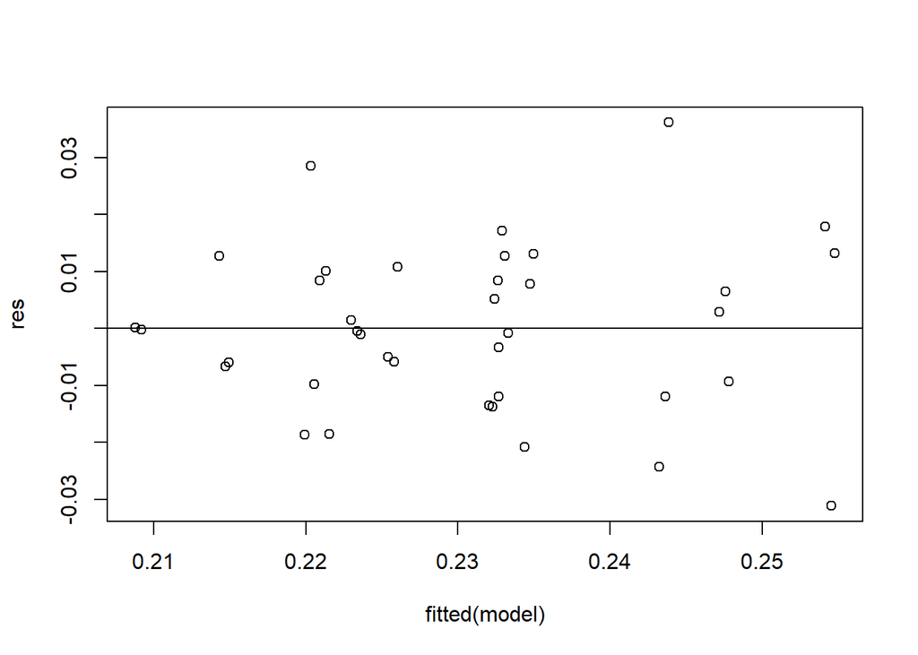

```r
res <- resid(model)

#produce residual vs. fitted plot
plot(fitted(model), res)

#add a horizontal line at 0
abline(0,0)
```

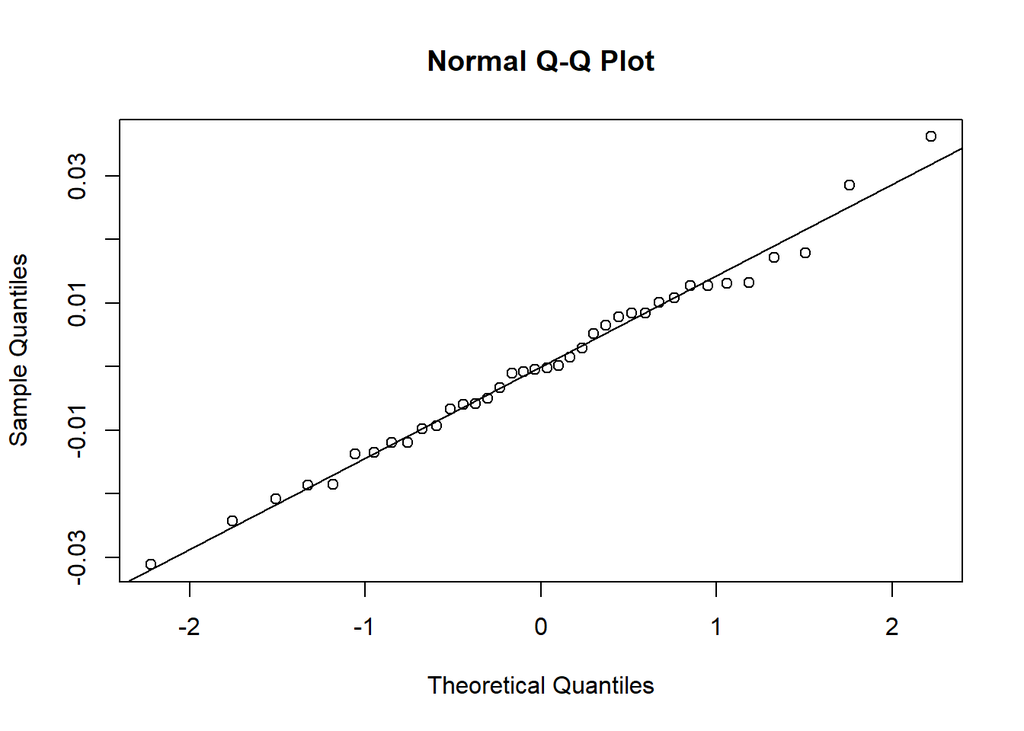

```r
#create Q-Q plot for residuals
qqnorm(res)

#add a straight diagonal line to the plot
qqline(res)
```

### Area

```r
model <- lmer(Area ~ Treatment + (1|Female), data = Thawed9sep_CV)
summary(model)
```

```
## Linear mixed model fit by REML ['lmerMod']
## Formula: Area ~ Treatment + (1 | Female)
##    Data: Thawed9sep_CV
##
## REML criterion at convergence: -247.9
##
## Scaled residuals:
##      Min       1Q   Median       3Q      Max
## -1.79922 -0.45371  0.01499  0.58154  1.88865
##
## Random effects:
##  Groups   Name        Variance  Std.Dev.
##  Female   (Intercept) 3.231e-07 0.0005684
##  Residual             1.496e-06 0.0012232
## Number of obs: 38, groups:  Female, 3
##
## Fixed effects:
##                                Estimate Std. Error t value
## (Intercept)                   1.443e-02  9.332e-04  15.458
## TreatmentDMSO 10% + Suc 0.1M -1.588e-04  1.123e-03  -0.141
## TreatmentDMSO 10% + Tre 0.1M -5.088e-04  1.123e-03  -0.453
## TreatmentDMSO 5%              9.124e-05  1.123e-03   0.081
## TreatmentDMSO 5% + Suc 0.1M   7.412e-04  1.123e-03   0.660
## TreatmentDMSO 5% + Tre 0.1M  -2.921e-04  1.123e-03  -0.260
## TreatmentFSW                  6.079e-04  1.123e-03   0.541
## TreatmentPG 10%               2.968e-04  1.123e-03   0.264
## TreatmentPG 10% + Suc 0.1M   -6.254e-04  1.123e-03  -0.557
## TreatmentPG 10% + Tre 0.1M    4.124e-05  1.123e-03   0.037
## TreatmentPG 5%               -2.921e-04  1.123e-03  -0.260
## TreatmentPG 5% + Suc 0.1M    -3.208e-06  1.123e-03  -0.003
## TreatmentPG 5% + Tre 0.1M     3.079e-04  1.123e-03   0.274
```

```
##
## Correlation matrix not shown by default, as p = 13 > 12.
## Use print(x, correlation=TRUE)  or
##     vcov(x)        if you need it
```

```r
car::Anova(model)
```

```
## Analysis of Deviance Table (Type II Wald chisquare tests)
##
## Response: Area
##            Chisq Df Pr(>Chisq)
## Treatment 3.9185 12     0.9849
```

Check model assumptions:

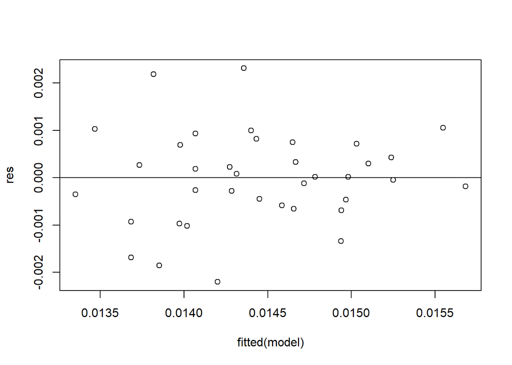

```r
res <- resid(model)

#produce residual vs. fitted plot
plot(fitted(model), res)

#add a horizontal line at 0
abline(0,0)
```

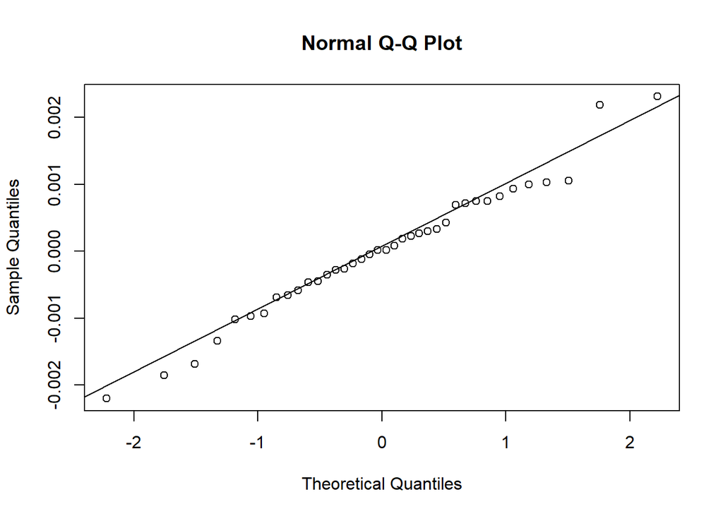

```r
#create Q-Q plot for residuals
qqnorm(res)

#add a straight diagonal line to the plot
qqline(res)
```

### Membrane detachment

```r
model <- lmer(Membrane_thickness ~ Treatment+ (1|Female), data = Thawed9sep_CV)
```

```
## boundary (singular) fit: see help('isSingular')
```

```r
summary(model)
```

```
## Linear mixed model fit by REML ['lmerMod']
## Formula: Membrane_thickness ~ Treatment + (1 | Female)
##    Data: Thawed9sep_CV
##
## REML criterion at convergence: -187.8
##
## Scaled residuals:
##      Min       1Q   Median       3Q      Max
## -1.77119 -0.47811 -0.03498  0.54224  1.94481
##
## Random effects:
##  Groups   Name        Variance  Std.Dev.
##  Female   (Intercept) 0.000e+00 0.000000
##  Residual             1.838e-05 0.004288
## Number of obs: 38, groups:  Female, 3
##
## Fixed effects:
##                                Estimate Std. Error t value
## (Intercept)                   0.0170000  0.0030319   5.607
## TreatmentDMSO 10% + Suc 0.1M  0.0025778  0.0039142   0.659
## TreatmentDMSO 10% + Tre 0.1M -0.0031667  0.0039142  -0.809
## TreatmentDMSO 5%             -0.0054000  0.0039142  -1.380
## TreatmentDMSO 5% + Suc 0.1M  -0.0034333  0.0039142  -0.877
## TreatmentDMSO 5% + Tre 0.1M  -0.0056333  0.0039142  -1.439
## TreatmentFSW                 -0.0011167  0.0039142  -0.285
## TreatmentPG 10%               0.0030556  0.0039142   0.781
## TreatmentPG 10% + Suc 0.1M   -0.0030000  0.0039142  -0.766
## TreatmentPG 10% + Tre 0.1M   -0.0035667  0.0039142  -0.911
## TreatmentPG 5%               -0.0054167  0.0039142  -1.384
## TreatmentPG 5% + Suc 0.1M    -0.0010056  0.0039142  -0.257
## TreatmentPG 5% + Tre 0.1M    -0.0009333  0.0039142  -0.238
```

```
##
## Correlation matrix not shown by default, as p = 13 > 12.
## Use print(x, correlation=TRUE)  or
##     vcov(x)        if you need it
```

```
## optimizer (nloptwrap) convergence code: 0 (OK)
## boundary (singular) fit: see help('isSingular')
```

```r
car::Anova(model)
```

```
## Analysis of Deviance Table (Type II Wald chisquare tests)
##
## Response: Membrane_thickness
##            Chisq Df Pr(>Chisq)
## Treatment 15.528 12     0.2138
```

Check model assumptions:

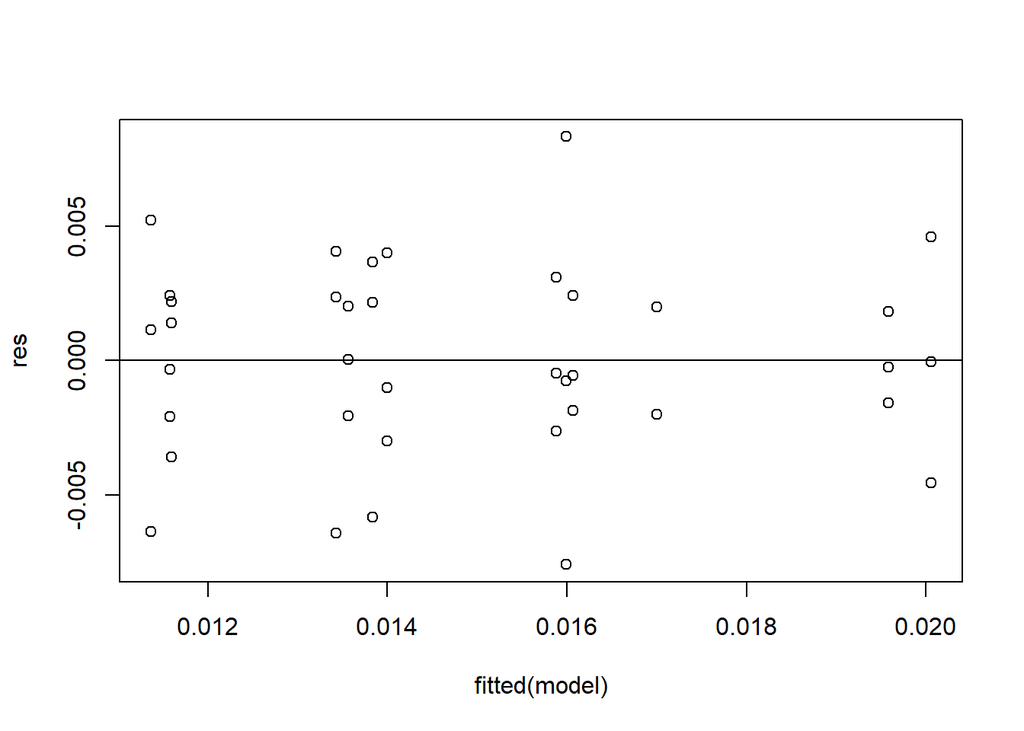

```r
res <- resid(model)

#produce residual vs. fitted plot
plot(fitted(model), res)

#add a horizontal line at 0
abline(0,0)
```

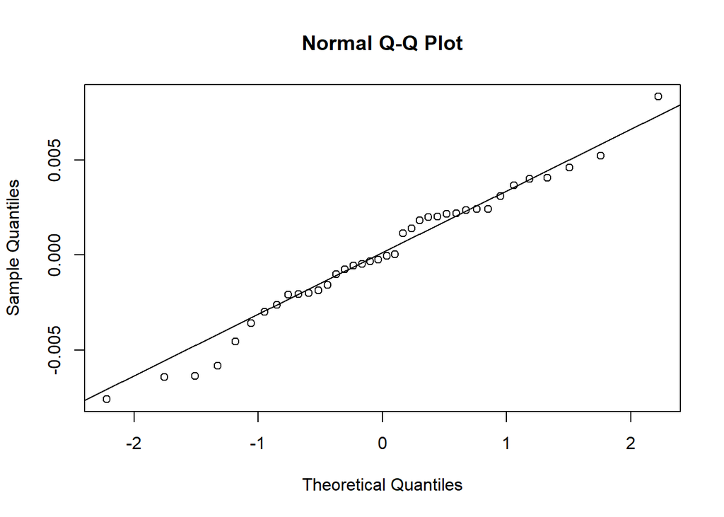

```r
#create Q-Q plot for residuals
qqnorm(res)

#add a straight diagonal line to the plot
qqline(res)
```

### Cellular damage

```r
model <- lmer(Cellular_damage ~ Treatment + (1|Female), data = Thawed9sep_CV)
summary(model)
```

```
## Linear mixed model fit by REML ['lmerMod']
## Formula: Cellular_damage ~ Treatment + (1 | Female)
##    Data: Thawed9sep_CV
##
## REML criterion at convergence: 255.8
##
## Scaled residuals:
##     Min      1Q  Median      3Q     Max
## -1.4962 -0.6039 -0.1278  0.6620  1.8649
##
## Random effects:
##  Groups   Name        Variance Std.Dev.
##  Female   (Intercept)  40.89    6.395
##  Residual             902.02   30.034
## Number of obs: 38, groups:  Female, 3
##
## Fixed effects:
##                              Estimate Std. Error t value
## (Intercept)                    53.302     21.658   2.461
## TreatmentDMSO 10% + Suc 0.1M   17.809     27.497   0.648
## TreatmentDMSO 10% + Tre 0.1M  -44.969     27.497  -1.635
## TreatmentDMSO 5%               10.031     27.497   0.365
## TreatmentDMSO 5% + Suc 0.1M   -16.635     27.497  -0.605
## TreatmentDMSO 5% + Tre 0.1M   -33.302     27.497  -1.211
## TreatmentFSW                   -6.635     27.497  -0.241
## TreatmentPG 10%                38.365     27.497   1.395
## TreatmentPG 10% + Suc 0.1M    -33.302     27.497  -1.211
## TreatmentPG 10% + Tre 0.1M    -11.635     27.497  -0.423
## TreatmentPG 5%                 21.698     27.497   0.789
## TreatmentPG 5% + Suc 0.1M       7.809     27.497   0.284
## TreatmentPG 5% + Tre 0.1M      23.365     27.497   0.850
```

```
##
## Correlation matrix not shown by default, as p = 13 > 12.
## Use print(x, correlation=TRUE)  or
##     vcov(x)        if you need it
```

```r
car::Anova(model)
```

```
## Analysis of Deviance Table (Type II Wald chisquare tests)
##
## Response: Cellular_damage
##            Chisq Df Pr(>Chisq)
## Treatment 25.291 12     0.0135 *
## ---
## Signif. codes:  0 '***' 0.001 '**' 0.01 '*' 0.05 '.' 0.1 ' ' 1
```

Contrasts:

```r
emmeans(model, specs = pairwise ~ Treatment, type = "response", adjust = "none")
```

```
## $emmeans
##  Treatment           emmean   SE   df lower.CL upper.CL
##  DMSO 10%             53.30 22.0 24.9    7.899     98.7
##  DMSO 10% + Suc 0.1M  71.11 17.7 24.5   34.558    107.7
##  DMSO 10% + Tre 0.1M   8.33 17.7 24.5  -28.220     44.9
##  DMSO 5%              63.33 17.7 24.5   26.780     99.9
##  DMSO 5% + Suc 0.1M   36.67 17.7 24.5    0.114     73.2
##  DMSO 5% + Tre 0.1M   20.00 17.7 24.5  -16.553     56.6
##  FSW                  46.67 17.7 24.5   10.114     83.2
##  PG 10%               91.67 17.7 24.5   55.114    128.2
##  PG 10% + Suc 0.1M    20.00 17.7 24.5  -16.553     56.6
##  PG 10% + Tre 0.1M    41.67 17.7 24.5    5.114     78.2
##  PG 5%                75.00 17.7 24.5   38.447    111.6
##  PG 5% + Suc 0.1M     61.11 17.7 24.5   24.558     97.7
##  PG 5% + Tre 0.1M     76.67 17.7 24.5   40.114    113.2
##
## Degrees-of-freedom method: kenward-roger
## Confidence level used: 0.95
##
## $contrasts
##  contrast                                      estimate   SE   df t.ratio
##  DMSO 10% - (DMSO 10% + Suc 0.1M)                -17.81 27.8 23.5  -0.641
##  DMSO 10% - (DMSO 10% + Tre 0.1M)                 44.97 27.8 23.5   1.618
##  DMSO 10% - DMSO 5%                              -10.03 27.8 23.5  -0.361
##  DMSO 10% - (DMSO 5% + Suc 0.1M)                  16.64 27.8 23.5   0.598
##  DMSO 10% - (DMSO 5% + Tre 0.1M)                  33.30 27.8 23.5   1.198
##  DMSO 10% - FSW                                    6.64 27.8 23.5   0.239
##  DMSO 10% - PG 10%                               -38.36 27.8 23.5  -1.380
##  DMSO 10% - (PG 10% + Suc 0.1M)                   33.30 27.8 23.5   1.198
##  DMSO 10% - (PG 10% + Tre 0.1M)                   11.64 27.8 23.5   0.419
##  DMSO 10% - PG 5%                                -21.70 27.8 23.5  -0.781
##  DMSO 10% - (PG 5% + Suc 0.1M)                    -7.81 27.8 23.5  -0.281
##  DMSO 10% - (PG 5% + Tre 0.1M)                   -23.36 27.8 23.5  -0.840
##  (DMSO 10% + Suc 0.1M) - (DMSO 10% + Tre 0.1M)    62.78 24.5 23.0   2.560
##  (DMSO 10% + Suc 0.1M) - DMSO 5%                   7.78 24.5 23.0   0.317
##  (DMSO 10% + Suc 0.1M) - (DMSO 5% + Suc 0.1M)     34.44 24.5 23.0   1.405
##  (DMSO 10% + Suc 0.1M) - (DMSO 5% + Tre 0.1M)     51.11 24.5 23.0   2.084
##  (DMSO 10% + Suc 0.1M) - FSW                      24.44 24.5 23.0   0.997
##  (DMSO 10% + Suc 0.1M) - PG 10%                  -20.56 24.5 23.0  -0.838
##  (DMSO 10% + Suc 0.1M) - (PG 10% + Suc 0.1M)      51.11 24.5 23.0   2.084
```

[output cut: 125 more lines]

```
##   0.5035
##   0.2253
##   0.5467
##   0.3861
##   0.0348
##   0.1072
##   0.0302
##   0.1872
##   0.4359
##   0.1669
##   0.5766
##   0.9464
##   0.5321
##
## Degrees-of-freedom method: kenward-roger
```

Check model assumptions:

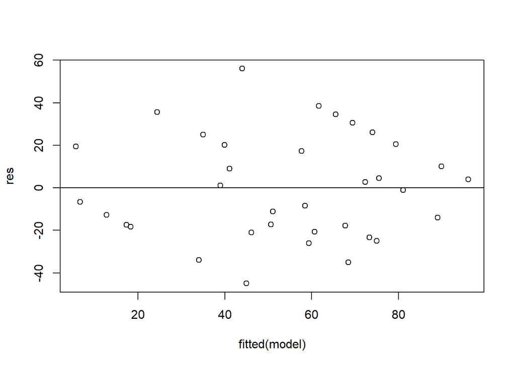

```r
res <- resid(model)

#produce residual vs. fitted plot
plot(fitted(model), res)

#add a horizontal line at 0
abline(0,0)
```

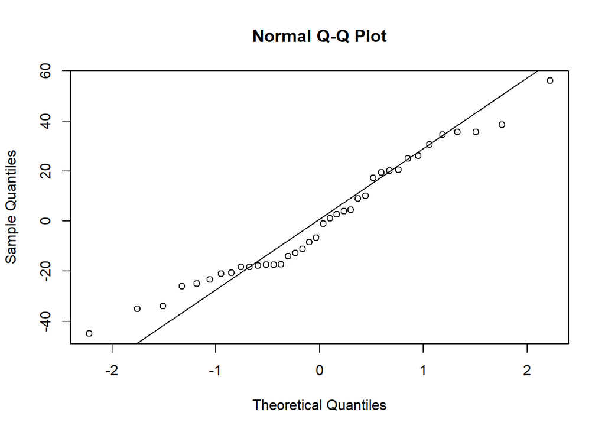

```r
#create Q-Q plot for residuals
qqnorm(res)

#add a straight diagonal line to the plot
qqline(res)
```

_________________________________________________________

# **8.** Experiment 7: Effects of increased CPA exposure

## **8a)** Import data

```r
Pre_germlings <- read.csv("Data_cryo/Germling_thawed_26sep2024.csv")
```

## **8b)** Data structure and summary

1. Check structure

```r
str(Pre_germlings)
```

```
## 'data.frame':    158 obs. of  16 variables:
##  $ Method            : chr  "Cryovial" "Cryovial" "Cryovial" "Cryovial" ...
##  $ Number            : int  1 1 2 2 3 4 4 4 4 5 ...
##  $ CPA               : chr  "DMSO" "DMSO" "PG" "PG" ...
##  $ Concentration     : int  10 10 20 20 10 20 20 20 20 20 ...
##  $ Equilibration     : int  15 15 15 15 15 15 15 15 15 15 ...
##  $ Treatment         : chr  "DMSO 10%" "DMSO 10%" "PG 20%" "PG 20%" ...
##  $ Site              : chr  "South Cronulla" "South Cronulla" "South Cronulla" "South Cronulla" ...
##  $ Date              : chr  "25-Sep-24" "25-Sep-24" "25-Sep-24" "25-Sep-24" ...
##  $ Folder            : chr  "Thawing_0oct" "Thawing_0oct" "Thawing_0oct" "Thawing_0oct" ...
##  $ Photo             : chr  "CV_1_.jpg" "CV_1_.jpg" "CV_2_.jpg" "CV_2_.jpg" ...
##  $ Replicate         : int  1 2 1 2 1 1 2 3 4 1 ...
##  $ Length            : num  0.197 0.19 0.183 0.189 0.209 0.201 0.189 0.18 0.194 0.208 ...
##  $ Area              : num  0.016 0.015 0.014 0.015 0.015 0.016 0.016 0.014 0.015 0.017 ...
##  $ Colour            : int  2 2 2 2 3 2 2 2 2 2 ...
##  $ Membrane_thickness: num  0.014 0.009 0.014 0.011 0.015 0.018 0.011 0.019 0.015 0.007 ...
##  $ Cellular_damage   : chr  "No" "No" "Yes" "Yes" ...
```

```r
Pre_germlings$Equilibration <- as.factor(Pre_germlings$Equilibration)
```

2. Calculate mean value for each female

```r
Pre_germlings_rep <- Pre_germlings %>%
group_by (Treatment, Equilibration,Method, Number) %>%
summarise(Length = mean(Length), Area = mean(Area), Colour = mean(Colour), Membrane_thickness = mean(Membrane_thickness),
    Cellular_damage = sum(Cellular_damage == "Yes", na.rm = TRUE) * 100 / n())
```

[output not shown]

```r
Pre_mean <- Pre_germlings_rep  %>%
  group_by (Treatment, , Equilibration,Method) %>%
  summarise(MeanLength = mean(Length),n = n(), sd_l = sd(Length), se_l = sd_l/sqrt(n), MeanArea = mean(Area),n = n(), sd_a = sd(Area), se_a = sd_a/sqrt(n), MeanColour = mean(Colour),n = n(), sd_c = sd(Colour), se_c = sd_c/sqrt(n), MeanMembrane = mean(Membrane_thickness),n = n(), sd_m = sd(Membrane_thickness), se_m = sd_m/sqrt(n), MeanDamage = mean(Cellular_damage),n = n(), sd_d = sd(Cellular_damage), se_d = sd_d/sqrt(n))
```

## **8c)** Visualise data

### Germling length

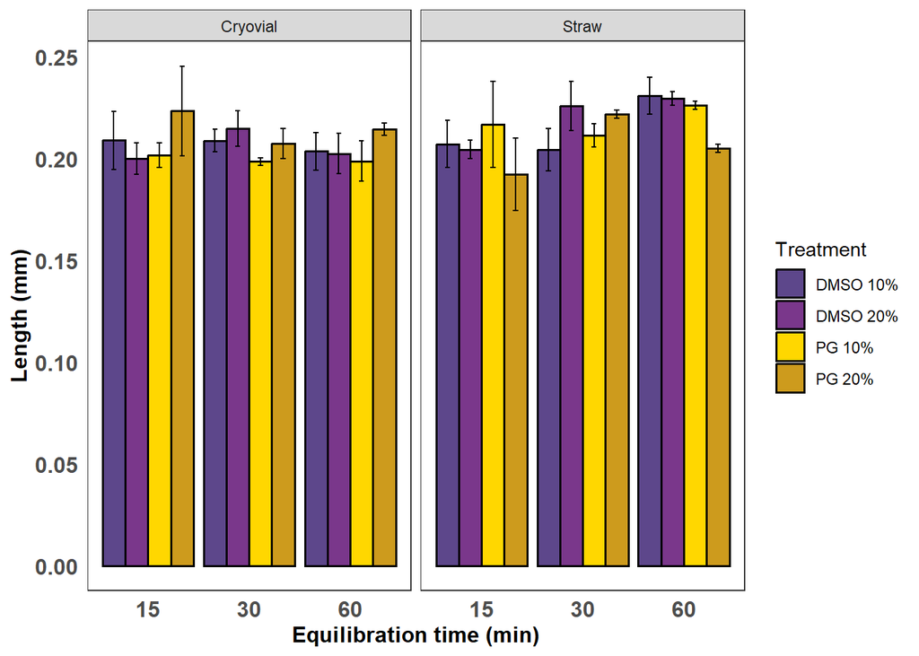

```r
Pre_mean  %>%
ggplot(aes(x= Equilibration, y= MeanLength, fill = Treatment)) +
  geom_bar(stat="identity", color="black",
           position=position_dodge(), linewidth = 0.6) +
 geom_errorbar(aes(ymin=MeanLength-se_l, ymax=MeanLength+se_l), width=.2, position=position_dodge(0.9)) +
Theme1 +
labs( y="Length (mm)", x="Equilibration time (min)")   +
  scale_fill_viridis(discrete = TRUE) +
  facet_wrap(~Method) +
scale_fill_manual(
    values = c("DMSO 10%" = "mediumpurple4", "DMSO 20%" = "mediumorchid4", "PG 10%" = "gold", "PG 20%" = "goldenrod3"))
```

```r
ggsave("E8_length_cv.jpeg", width = 17, height = 7, units = "cm")
```

### Germling Area

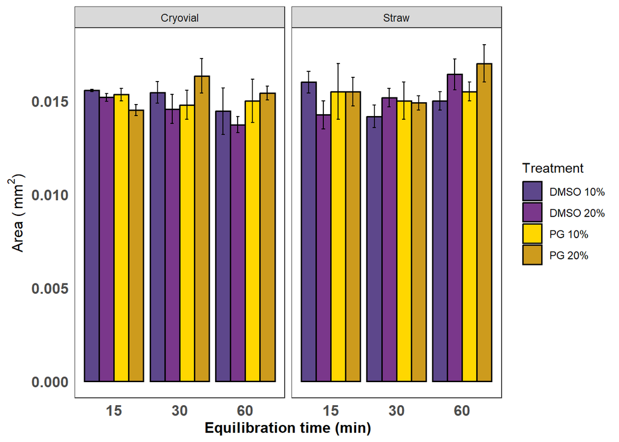

```r
Pre_mean  %>%
ggplot(aes(x= Equilibration, y= MeanArea, fill = Treatment)) +
  geom_bar(stat="identity", color="black",
           position=position_dodge(), linewidth = 0.6) +
geom_errorbar(aes(ymin=MeanArea-se_a, ymax=MeanArea+se_a), width=.2, position=position_dodge(0.9))+
Theme1 +
labs( y=expression("Area ("~mm^2*")"), x="Equilibration time (min)")   +
  scale_fill_viridis(discrete = TRUE) +
  facet_wrap(~Method) +
scale_fill_manual(
    values = c("DMSO 10%" = "mediumpurple4", "DMSO 20%" = "mediumorchid4", "PG 10%" = "gold", "PG 20%" = "goldenrod3"))
```

```r
ggsave("E8_area.jpeg", width = 17, height = 7, units = "cm")
```

### Germling membrane detachment

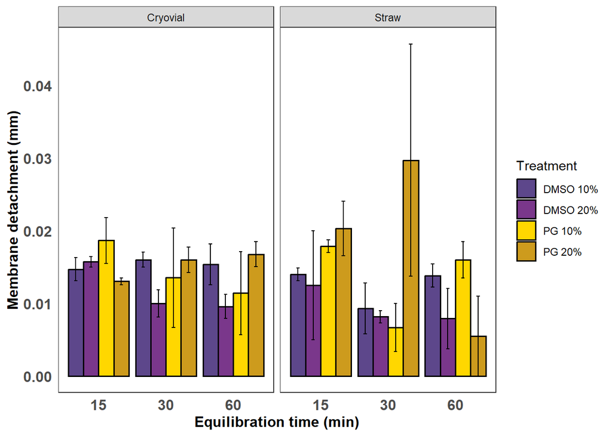

```r
Pre_mean  %>%
ggplot(aes(x= Equilibration, y= MeanMembrane, fill = Treatment)) +
  geom_bar(stat="identity", color="black",
           position=position_dodge(), linewidth = 0.6) +
 geom_errorbar(aes(ymin=MeanMembrane-se_m, ymax=MeanMembrane+se_m), width=.2, position=position_dodge(0.9)) +
Theme1 +
labs( y="Membrane detachment (mm)", x="Equilibration time (min)")   +
  facet_wrap(~Method) +
scale_fill_manual(
    values = c("DMSO 10%" = "mediumpurple4", "DMSO 20%" = "mediumorchid4", "PG 10%" = "gold", "PG 20%" = "goldenrod3"))
```

```r
ggsave("E8_membrane.jpeg", width = 17, height = 7, units = "cm")
```

### Germling cellular damage

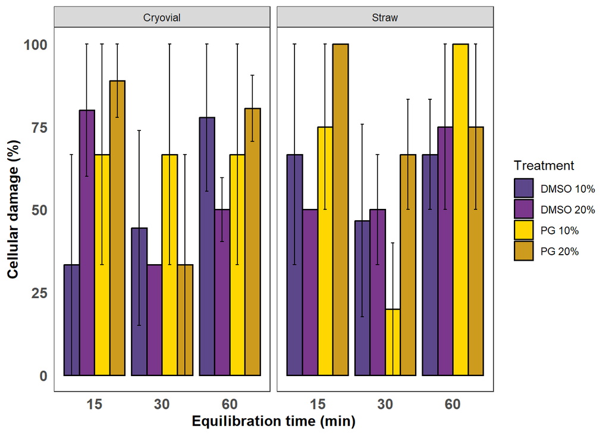

```r
Pre_mean  %>%
ggplot(aes(x= Equilibration, y= MeanDamage, fill = Treatment)) +
  geom_bar(stat="identity", color="black",
           position=position_dodge(), linewidth = 0.6) +
geom_errorbar(aes(ymin=MeanDamage-se_d, ymax=MeanDamage+se_d), width=.2, position=position_dodge(0.9)) +
Theme1 +
labs( y="Cellular damage (%)", x="Equilibration time (min)")   +
  facet_wrap(~Method) +
scale_fill_manual(
    values = c("DMSO 10%" = "mediumpurple4", "DMSO 20%" = "mediumorchid4", "PG 10%" = "gold", "PG 20%" = "goldenrod3"))
```

```r
ggsave("E7_damage.jpeg", width = 17, height = 7, units = "cm")
```

## **8d)** Statistical analyses

### Length

```r
Thawed9sep_female$Female <- as.factor(Thawed9sep_female$Female)
Thawed9sep_CV <- filter(Thawed9sep_female, Method == "Cryovial")
```

```r
model <- lm(Length ~ Treatment*Method*Equilibration, data = Pre_germlings_rep)
summary(model)
```

```
##
## Call:
## lm(formula = Length ~ Treatment * Method * Equilibration, data = Pre_germlings_rep)
##
## Residuals:
##       Min        1Q    Median        3Q       Max
## -0.037333 -0.009158 -0.001125  0.007417  0.038667
##
## Coefficients:
##                                                 Estimate Std. Error t value
## (Intercept)                                    0.2090000  0.0100482  20.800
## TreatmentDMSO 20%                             -0.0090333  0.0142103  -0.636
## TreatmentPG 10%                               -0.0073333  0.0142103  -0.516
## TreatmentPG 20%                                0.0143333  0.0142103   1.009
## MethodStraw                                   -0.0018333  0.0142103  -0.129
## Equilibration30                               -0.0002778  0.0142103  -0.020
## Equilibration60                               -0.0054444  0.0142103  -0.383
## TreatmentDMSO 20%:MethodStraw                  0.0063667  0.0213154   0.299
## TreatmentPG 10%:MethodStraw                    0.0169167  0.0213154   0.794
## TreatmentPG 20%:MethodStraw                   -0.0293333  0.0200964  -1.460
## TreatmentDMSO 20%:Equilibration30              0.0150889  0.0200964   0.751
## TreatmentPG 10%:Equilibration30               -0.0028333  0.0200964  -0.141
## TreatmentPG 20%:Equilibration30               -0.0157222  0.0200964  -0.782
## TreatmentDMSO 20%:Equilibration60              0.0078944  0.0200964   0.393
## TreatmentPG 10%:Equilibration60                0.0024444  0.0200964   0.122
## TreatmentPG 20%:Equilibration60               -0.0035833  0.0200964  -0.178
## MethodStraw:Equilibration30                   -0.0026222  0.0200964  -0.130
## MethodStraw:Equilibration60                    0.0291111  0.0200964   1.449
## TreatmentDMSO 20%:MethodStraw:Equilibration30  0.0091444  0.0301445   0.303
## TreatmentPG 10%:MethodStraw:Equilibration30    0.0002833  0.0301445   0.009
## TreatmentPG 20%:MethodStraw:Equilibration30    0.0483722  0.0284205   1.702
## TreatmentDMSO 20%:MethodStraw:Equilibration60 -0.0065611  0.0292952  -0.224
## TreatmentPG 10%:MethodStraw:Equilibration60   -0.0167361  0.0301445  -0.555
## TreatmentPG 20%:MethodStraw:Equilibration60   -0.0072500  0.0292952  -0.247
##                                               Pr(>|t|)
## (Intercept)                                     <2e-16 ***
## TreatmentDMSO 20%                               0.5284
## TreatmentPG 10%                                 0.6085
## TreatmentPG 20%                                 0.3189
## MethodStraw                                     0.8980
```

[output cut: 10 more lines]

```
## TreatmentPG 20%:Equilibration60                 0.8593
## MethodStraw:Equilibration30                     0.8968
## MethodStraw:Equilibration60                     0.1549
## TreatmentDMSO 20%:MethodStraw:Equilibration30   0.7631
## TreatmentPG 10%:MethodStraw:Equilibration30     0.9925
## TreatmentPG 20%:MethodStraw:Equilibration30     0.0961 .
## TreatmentDMSO 20%:MethodStraw:Equilibration60   0.8239
## TreatmentPG 10%:MethodStraw:Equilibration60     0.5817
## TreatmentPG 20%:MethodStraw:Equilibration60     0.8057
## ---
## Signif. codes:  0 '***' 0.001 '**' 0.01 '*' 0.05 '.' 0.1 ' ' 1
##
## Residual standard error: 0.0174 on 42 degrees of freedom
## Multiple R-squared:  0.3689, Adjusted R-squared:  0.02329
## F-statistic: 1.067 on 23 and 42 DF,  p-value: 0.4157
```

```r
car::Anova(model)
```

```
## Anova Table (Type II tests)
##
## Response: Length
##                                   Sum Sq Df F value  Pr(>F)
## Treatment                      0.0001971  3  0.2169 0.88416
## Method                         0.0009055  1  2.9895 0.09115 .
## Equilibration                  0.0004886  2  0.8066 0.45318
## Treatment:Method               0.0015943  3  1.7545 0.17056
## Treatment:Equilibration        0.0009562  6  0.5262 0.78520
## Method:Equilibration           0.0013959  2  2.3042 0.11233
## Treatment:Method:Equilibration 0.0016245  6  0.8939 0.50823
## Residuals                      0.0127217 42
## ---
## Signif. codes:  0 '***' 0.001 '**' 0.01 '*' 0.05 '.' 0.1 ' ' 1
```

Check model assumptions:

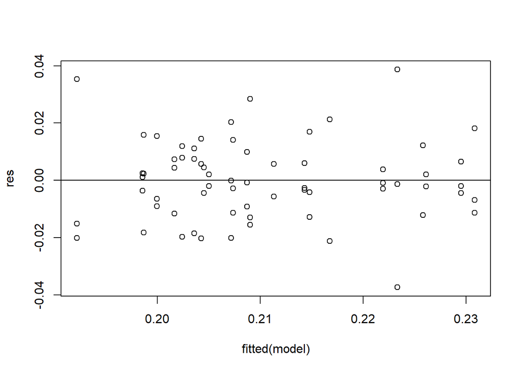

```r
res <- resid(model)

#produce residual vs. fitted plot
plot(fitted(model), res)

#add a horizontal line at 0
abline(0,0)
```

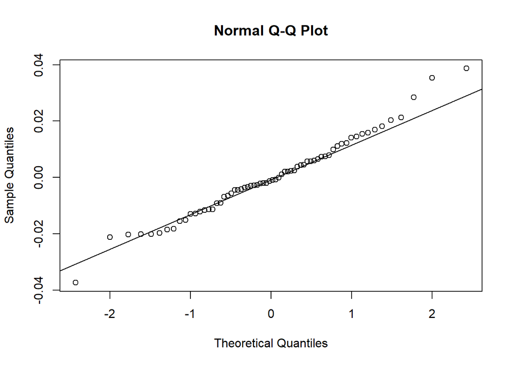

```r
#create Q-Q plot for residuals
qqnorm(res)

#add a straight diagonal line to the plot
qqline(res)
```

### Area

```r
model <- lm(Area ~ Treatment*Method*Equilibration, data = Pre_germlings_rep)
summary(model)
```

```
##
## Call:
## lm(formula = Area ~ Treatment * Method * Equilibration, data = Pre_germlings_rep)
##
## Residuals:
##        Min         1Q     Median         3Q        Max
## -0.0024444 -0.0007083  0.0000000  0.0007292  0.0020000
##
## Coefficients:
##                                                 Estimate Std. Error t value
## (Intercept)                                    0.0155556  0.0006885  22.593
## TreatmentDMSO 20%                             -0.0003722  0.0009737  -0.382
## TreatmentPG 10%                               -0.0002222  0.0009737  -0.228
## TreatmentPG 20%                               -0.0010556  0.0009737  -1.084
## MethodStraw                                    0.0004444  0.0009737   0.456
## Equilibration30                               -0.0001111  0.0009737  -0.114
## Equilibration60                               -0.0011111  0.0009737  -1.141
## TreatmentDMSO 20%:MethodStraw                 -0.0013778  0.0014605  -0.943
## TreatmentPG 10%:MethodStraw                   -0.0002778  0.0014605  -0.190
## TreatmentPG 20%:MethodStraw                    0.0005556  0.0013770   0.403
## TreatmentDMSO 20%:Equilibration30             -0.0005167  0.0013770  -0.375
## TreatmentPG 10%:Equilibration30               -0.0004444  0.0013770  -0.323
## TreatmentPG 20%:Equilibration30                0.0019444  0.0013770   1.412
## TreatmentDMSO 20%:Equilibration60             -0.0003500  0.0013770  -0.254
## TreatmentPG 10%:Equilibration60                0.0007778  0.0013770   0.565
## TreatmentPG 20%:Equilibration60                0.0020278  0.0013770   1.473
## MethodStraw:Equilibration30                   -0.0017222  0.0013770  -1.251
## MethodStraw:Equilibration60                    0.0001111  0.0013770   0.081
## TreatmentDMSO 20%:MethodStraw:Equilibration30  0.0032667  0.0020655   1.582
## TreatmentPG 10%:MethodStraw:Equilibration30    0.0017778  0.0020655   0.861
## TreatmentPG 20%:MethodStraw:Equilibration30   -0.0007222  0.0019474  -0.371
## TreatmentDMSO 20%:MethodStraw:Equilibration60  0.0035167  0.0020073   1.752
## TreatmentPG 10%:MethodStraw:Equilibration60    0.0002222  0.0020655   0.108
## TreatmentPG 20%:MethodStraw:Equilibration60    0.0004722  0.0020073   0.235
##                                               Pr(>|t|)
## (Intercept)                                     <2e-16 ***
## TreatmentDMSO 20%                               0.7042
## TreatmentPG 10%                                 0.8206
## TreatmentPG 20%                                 0.2845
## MethodStraw                                     0.6504
```

[output cut: 10 more lines]

```
## TreatmentPG 20%:Equilibration60                 0.1483
## MethodStraw:Equilibration30                     0.2180
## MethodStraw:Equilibration60                     0.9361
## TreatmentDMSO 20%:MethodStraw:Equilibration30   0.1213
## TreatmentPG 10%:MethodStraw:Equilibration30     0.3943
## TreatmentPG 20%:MethodStraw:Equilibration30     0.7126
## TreatmentDMSO 20%:MethodStraw:Equilibration60   0.0871 .
## TreatmentPG 10%:MethodStraw:Equilibration60     0.9148
## TreatmentPG 20%:MethodStraw:Equilibration60     0.8152
## ---
## Signif. codes:  0 '***' 0.001 '**' 0.01 '*' 0.05 '.' 0.1 ' ' 1
##
## Residual standard error: 0.001193 on 42 degrees of freedom
## Multiple R-squared:  0.3706, Adjusted R-squared:  0.02596
## F-statistic: 1.075 on 23 and 42 DF,  p-value: 0.4079
```

```r
car::Anova(model)
```

```
## Anova Table (Type II tests)
##
## Response: Area
##                                    Sum Sq Df F value  Pr(>F)
## Treatment                      4.0390e-06  3  0.9468 0.42668
## Method                         1.8930e-06  1  1.3314 0.25508
## Equilibration                  6.5600e-07  2  0.2306 0.79507
## Treatment:Method               1.9030e-06  3  0.4460 0.72140
## Treatment:Equilibration        8.1490e-06  6  0.9550 0.46697
## Method:Equilibration           9.8810e-06  2  3.4742 0.04015 *
## Treatment:Method:Equilibration 9.5990e-06  6  1.1250 0.36456
## Residuals                      5.9729e-05 42
## ---
## Signif. codes:  0 '***' 0.001 '**' 0.01 '*' 0.05 '.' 0.1 ' ' 1
```

Contrasts:

```r
emmeans(model, specs = pairwise ~ Method|Equilibration, type = "response", adjust = "none")
```

```
## NOTE: Results may be misleading due to involvement in interactions
```

```
## $emmeans
## Equilibration = 15:
##  Method   emmean       SE df lower.CL upper.CL
##  Cryovial 0.0151 0.000344 42   0.0144   0.0158
##  Straw    0.0153 0.000385 42   0.0145   0.0161
##
## Equilibration = 30:
##  Method   emmean       SE df lower.CL upper.CL
##  Cryovial 0.0153 0.000344 42   0.0146   0.0160
##  Straw    0.0148 0.000385 42   0.0140   0.0156
##
## Equilibration = 60:
##  Method   emmean       SE df lower.CL upper.CL
##  Cryovial 0.0146 0.000344 42   0.0140   0.0153
##  Straw    0.0160 0.000385 42   0.0152   0.0168
##
## Results are averaged over the levels of: Treatment
## Confidence level used: 0.95
##
## $contrasts
## Equilibration = 15:
##  contrast          estimate       SE df t.ratio p.value
##  Cryovial - Straw -0.000169 0.000516 42  -0.328  0.7444
##
## Equilibration = 30:
##  contrast          estimate       SE df t.ratio p.value
##  Cryovial - Straw  0.000472 0.000516 42   0.914  0.3657
##
## Equilibration = 60:
##  contrast          estimate       SE df t.ratio p.value
##  Cryovial - Straw -0.001333 0.000516 42  -2.582  0.0134
##
## Results are averaged over the levels of: Treatment
```

```r
emmeans(model, specs = pairwise ~ Equilibration|Method, type = "response", adjust = "none")
```

```
## NOTE: Results may be misleading due to involvement in interactions
```

```
## $emmeans
## Method = Cryovial:
##  Equilibration emmean       SE df lower.CL upper.CL
##  15            0.0151 0.000344 42   0.0144   0.0158
##  30            0.0153 0.000344 42   0.0146   0.0160
##  60            0.0146 0.000344 42   0.0140   0.0153
##
## Method = Straw:
##  Equilibration emmean       SE df lower.CL upper.CL
##  15            0.0153 0.000385 42   0.0145   0.0161
##  30            0.0148 0.000385 42   0.0140   0.0156
##  60            0.0160 0.000385 42   0.0152   0.0168
##
## Results are averaged over the levels of: Treatment
## Confidence level used: 0.95
##
## $contrasts
## Method = Cryovial:
##  contrast                           estimate       SE df t.ratio p.value
##  Equilibration15 - Equilibration30 -0.000135 0.000487 42  -0.277  0.7833
##  Equilibration15 - Equilibration60  0.000497 0.000487 42   1.021  0.3130
##  Equilibration30 - Equilibration60  0.000632 0.000487 42   1.298  0.2014
##
## Method = Straw:
##  contrast                           estimate       SE df t.ratio p.value
##  Equilibration15 - Equilibration30  0.000507 0.000544 42   0.931  0.3570
##  Equilibration15 - Equilibration60 -0.000667 0.000544 42  -1.225  0.2275
##  Equilibration30 - Equilibration60 -0.001174 0.000544 42  -2.156  0.0368
##
## Results are averaged over the levels of: Treatment
```

Check model assumptions:

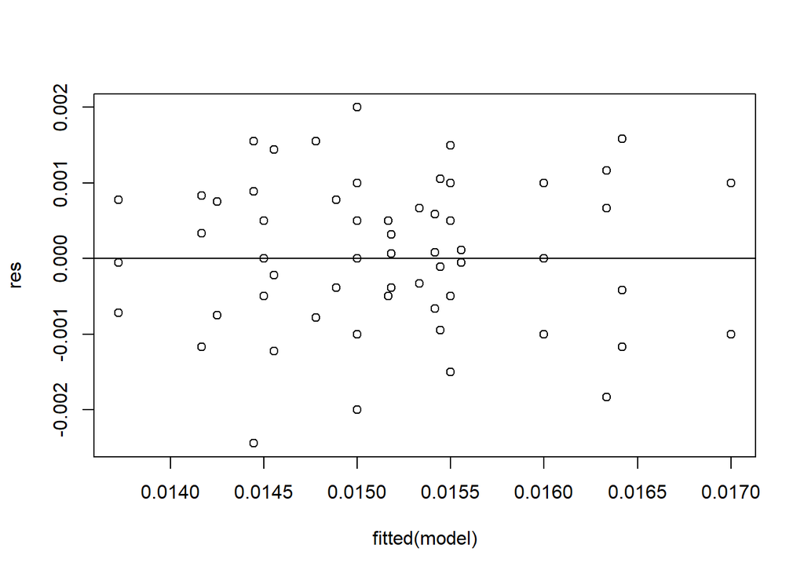

```r
res <- resid(model)

#produce residual vs. fitted plot
plot(fitted(model), res)

#add a horizontal line at 0
abline(0,0)
```

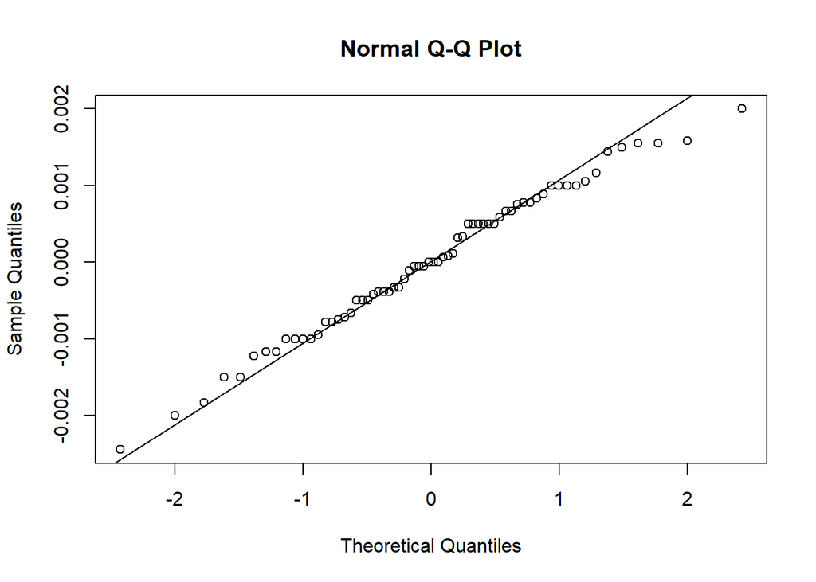

```r
#create Q-Q plot for residuals
qqnorm(res)

#add a straight diagonal line to the plot
qqline(res)
```

### Membrane detachment

```r
model <- lm(Membrane_thickness ~ Treatment*Method*Equilibration, data = Pre_germlings_rep)
summary(model)
```

```
##
## Call:
## lm(formula = Membrane_thickness ~ Treatment * Method * Equilibration,
##     data = Pre_germlings_rep)
##
## Residuals:
##       Min        1Q    Median        3Q       Max
## -0.019056 -0.002708  0.000000  0.002396  0.031778
##
## Coefficients:
##                                                 Estimate Std. Error t value
## (Intercept)                                    1.472e-02  4.639e-03   3.174
## TreatmentDMSO 20%                              1.028e-03  6.560e-03   0.157
## TreatmentPG 10%                                3.944e-03  6.560e-03   0.601
## TreatmentPG 20%                               -1.667e-03  6.560e-03  -0.254
## MethodStraw                                   -7.222e-04  6.560e-03  -0.110
## Equilibration30                                1.306e-03  6.560e-03   0.199
## Equilibration60                                6.667e-04  6.560e-03   0.102
## TreatmentDMSO 20%:MethodStraw                 -2.528e-03  9.841e-03  -0.257
## TreatmentPG 10%:MethodStraw                   -6.944e-05  9.841e-03  -0.007
## TreatmentPG 20%:MethodStraw                    8.000e-03  9.278e-03   0.862
## TreatmentDMSO 20%:Equilibration30             -7.056e-03  9.278e-03  -0.760
## TreatmentPG 10%:Equilibration30               -6.417e-03  9.278e-03  -0.692
## TreatmentPG 20%:Equilibration30                1.639e-03  9.278e-03   0.177
## TreatmentDMSO 20%:Equilibration60             -6.833e-03  9.278e-03  -0.737
## TreatmentPG 10%:Equilibration60               -7.917e-03  9.278e-03  -0.853
## TreatmentPG 20%:Equilibration60                3.056e-03  9.278e-03   0.329
## MethodStraw:Equilibration30                   -6.006e-03  9.278e-03  -0.647
## MethodStraw:Equilibration60                   -8.333e-04  9.278e-03  -0.090
## TreatmentDMSO 20%:MethodStraw:Equilibration30  7.422e-03  1.392e-02   0.533
## TreatmentPG 10%:MethodStraw:Equilibration30   -5.833e-05  1.392e-02  -0.004
## TreatmentPG 20%:MethodStraw:Equilibration30    1.245e-02  1.312e-02   0.949
## TreatmentDMSO 20%:MethodStraw:Equilibration60  2.417e-03  1.352e-02   0.179
## TreatmentPG 10%:MethodStraw:Equilibration60    6.208e-03  1.392e-02   0.446
## TreatmentPG 20%:MethodStraw:Equilibration60   -1.772e-02  1.352e-02  -1.310
##                                               Pr(>|t|)
## (Intercept)                                    0.00282 **
## TreatmentDMSO 20%                              0.87626
## TreatmentPG 10%                                0.55090
## TreatmentPG 20%                                0.80070
```

[output cut: 11 more lines]

```
## TreatmentPG 20%:Equilibration60                0.74354
## MethodStraw:Equilibration30                    0.52096
## MethodStraw:Equilibration60                    0.92886
## TreatmentDMSO 20%:MethodStraw:Equilibration30  0.59662
## TreatmentPG 10%:MethodStraw:Equilibration30    0.99668
## TreatmentPG 20%:MethodStraw:Equilibration30    0.34811
## TreatmentDMSO 20%:MethodStraw:Equilibration60  0.85904
## TreatmentPG 10%:MethodStraw:Equilibration60    0.65781
## TreatmentPG 20%:MethodStraw:Equilibration60    0.19719
## ---
## Signif. codes:  0 '***' 0.001 '**' 0.01 '*' 0.05 '.' 0.1 ' ' 1
##
## Residual standard error: 0.008035 on 42 degrees of freedom
## Multiple R-squared:  0.3796, Adjusted R-squared:  0.0399
## F-statistic: 1.117 on 23 and 42 DF,  p-value: 0.3678
```

```r
car::Anova(model)
```

```
## Anova Table (Type II tests)
##
## Response: Membrane_thickness
##                                    Sum Sq Df F value Pr(>F)
## Treatment                      0.00035315  3  1.8234 0.1576
## Method                         0.00000377  1  0.0584 0.8101
## Equilibration                  0.00011768  2  0.9115 0.4097
## Treatment:Method               0.00012955  3  0.6689 0.5759
## Treatment:Equilibration        0.00043794  6  1.1306 0.3615
## Method:Equilibration           0.00002468  2  0.1912 0.8267
## Treatment:Method:Equilibration 0.00052525  6  1.3560 0.2546
## Residuals                      0.00271145 42
```

Check model assumptions:

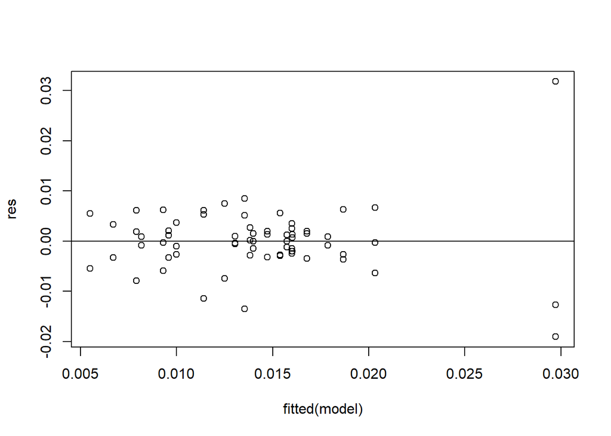

```r
res <- resid(model)

#produce residual vs. fitted plot
plot(fitted(model), res)

#add a horizontal line at 0
abline(0,0)
```

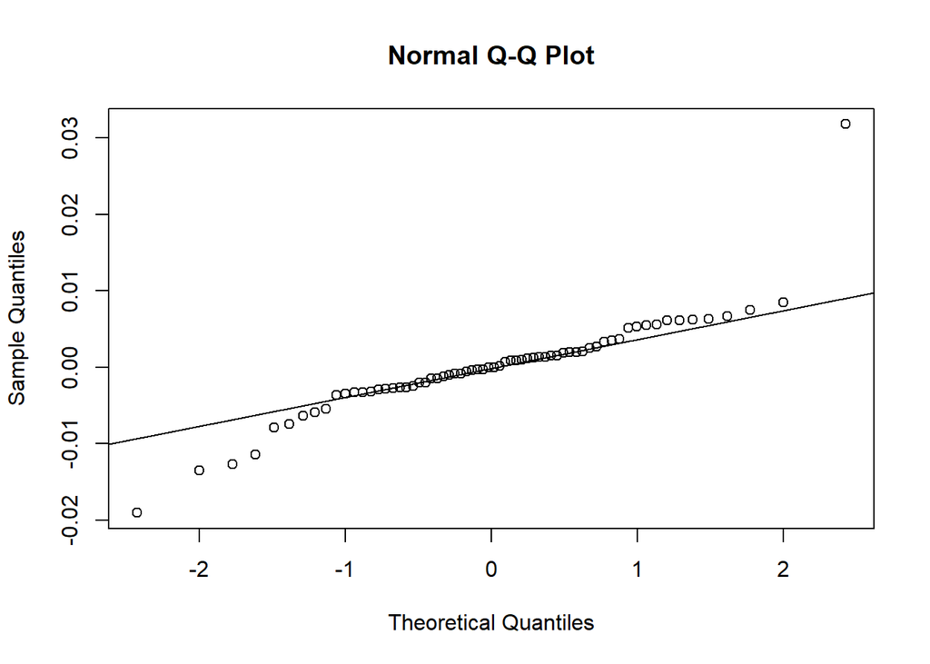

```r
#create Q-Q plot for residuals
qqnorm(res)

#add a straight diagonal line to the plot
qqline(res)
```

### Cellular damage

```r
model <- lm(Cellular_damage ~ Treatment*Method*Equilibration, data = Pre_germlings_rep)
summary(model)
```

```
##
## Call:
## lm(formula = Cellular_damage ~ Treatment * Method * Equilibration,
##     data = Pre_germlings_rep)
##
## Residuals:
##    Min     1Q Median     3Q    Max
## -66.67 -19.17   0.00  25.00  66.67
##
## Coefficients:
##                                               Estimate Std. Error t value
## (Intercept)                                      33.33      23.31   1.430
## TreatmentDMSO 20%                                46.67      32.96   1.416
## TreatmentPG 10%                                  33.33      32.96   1.011
## TreatmentPG 20%                                  55.56      32.96   1.685
## MethodStraw                                      33.33      32.96   1.011
## Equilibration30                                  11.11      32.96   0.337
## Equilibration60                                  44.44      32.96   1.348
## TreatmentDMSO 20%:MethodStraw                   -63.33      49.44  -1.281
## TreatmentPG 10%:MethodStraw                     -25.00      49.44  -0.506
## TreatmentPG 20%:MethodStraw                     -22.22      46.62  -0.477
## TreatmentDMSO 20%:Equilibration30               -57.78      46.62  -1.239
## TreatmentPG 10%:Equilibration30                 -11.11      46.62  -0.238
## TreatmentPG 20%:Equilibration30                 -66.67      46.62  -1.430
## TreatmentDMSO 20%:Equilibration60               -74.44      46.62  -1.597
## TreatmentPG 10%:Equilibration60                 -44.44      46.62  -0.953
## TreatmentPG 20%:Equilibration60                 -52.78      46.62  -1.132
## MethodStraw:Equilibration30                     -31.11      46.62  -0.667
## MethodStraw:Equilibration60                     -44.44      46.62  -0.953
## TreatmentDMSO 20%:MethodStraw:Equilibration30    77.78      69.92   1.112
## TreatmentPG 10%:MethodStraw:Equilibration30     -23.89      69.92  -0.342
## TreatmentPG 20%:MethodStraw:Equilibration30      53.33      65.93   0.809
## TreatmentDMSO 20%:MethodStraw:Equilibration60    99.44      67.95   1.463
## TreatmentPG 10%:MethodStraw:Equilibration60      69.44      69.92   0.993
## TreatmentPG 20%:MethodStraw:Equilibration60      27.78      67.95   0.409
##                                               Pr(>|t|)
## (Intercept)                                     0.1601
## TreatmentDMSO 20%                               0.1642
## TreatmentPG 10%                                 0.3177
## TreatmentPG 20%                                 0.0993 .
```

[output cut: 11 more lines]

```
## TreatmentPG 20%:Equilibration60                 0.2640
## MethodStraw:Equilibration30                     0.5082
## MethodStraw:Equilibration60                     0.3458
## TreatmentDMSO 20%:MethodStraw:Equilibration30   0.2723
## TreatmentPG 10%:MethodStraw:Equilibration30     0.7343
## TreatmentPG 20%:MethodStraw:Equilibration30     0.4231
## TreatmentDMSO 20%:MethodStraw:Equilibration60   0.1508
## TreatmentPG 10%:MethodStraw:Equilibration60     0.3263
## TreatmentPG 20%:MethodStraw:Equilibration60     0.6848
## ---
## Signif. codes:  0 '***' 0.001 '**' 0.01 '*' 0.05 '.' 0.1 ' ' 1
##
## Residual standard error: 40.37 on 42 degrees of freedom
## Multiple R-squared:  0.2843, Adjusted R-squared:  -0.1077
## F-statistic: 0.7252 on 23 and 42 DF,  p-value: 0.7933
```

```r
car::Anova(model)
```

```
## Anova Table (Type II tests)
##
## Response: Cellular_damage
##                                Sum Sq Df F value  Pr(>F)
## Treatment                        4082  3  0.8349 0.48232
## Method                            777  1  0.4765 0.49380
## Equilibration                   10149  2  3.1135 0.05484 .
## Treatment:Method                  526  3  0.1075 0.95526
## Treatment:Equilibration          3290  6  0.3365 0.91373
## Method:Equilibration              146  2  0.0449 0.95614
## Treatment:Method:Equilibration   8698  6  0.8895 0.51126
## Residuals                       68452 42
## ---
## Signif. codes:  0 '***' 0.001 '**' 0.01 '*' 0.05 '.' 0.1 ' ' 1
```

Check model assumptions:

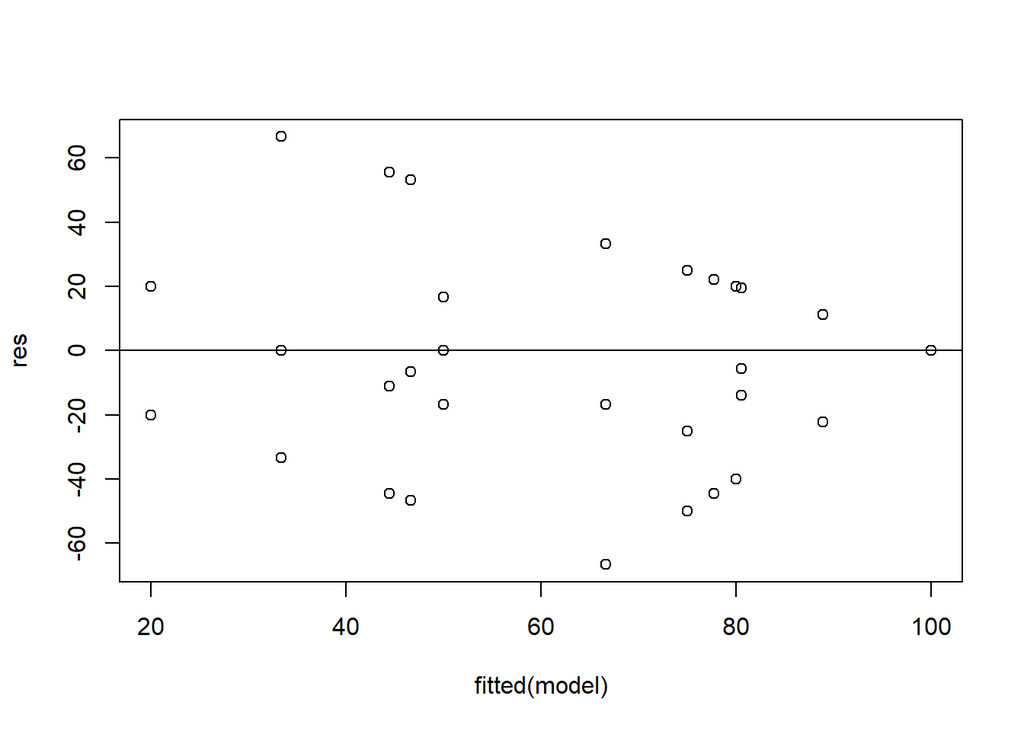

```r
res <- resid(model)

#produce residual vs. fitted plot
plot(fitted(model), res)

#add a horizontal line at 0
abline(0,0)
```

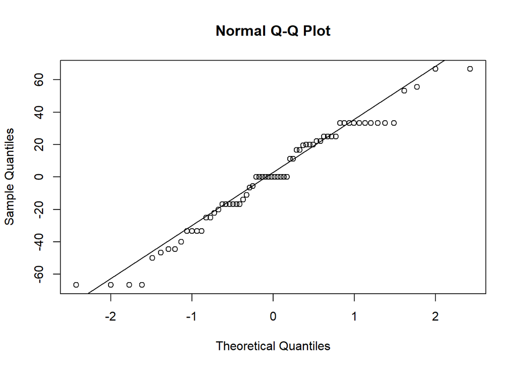

```r
#create Q-Q plot for residuals
qqnorm(res)

#add a straight diagonal line to the plot
qqline(res)
```

# **9.** R Session Information

In this section, information about the operating system and R packages attached during the production of this document can be found

```r
sessionInfo() %>% pander
```

**R version 4.4.1 (2024-06-14 ucrt)**

**Platform:** x86_64-w64-mingw32/x64

**locale:** *LC_COLLATE=English_Australia.utf8*, *LC_CTYPE=English_Australia.utf8*, *LC_MONETARY=English_Australia.utf8*, *LC_NUMERIC=C* and *LC_TIME=English_Australia.utf8*

**attached base packages:** *stats*, *graphics*, *grDevices*, *utils*, *datasets*, *methods* and *base*

**other attached packages:** *scales(v.1.3.0)*, *ggbreak(v.0.1.4)*, *viridis(v.0.6.5)*, *viridisLite(v.0.4.2)*, *MuMIn(v.1.48.4)*, *outliers(v.0.15)*, *corrplot(v.0.95)*, *wesanderson(v.0.3.7)*, *emmeans(v.1.10.2)*, *lme4(v.1.1-35.4)*, *Matrix(v.1.7-0)*, *pander(v.0.6.5)*, *ggplot2(v.3.5.1)*, *patchwork(v.1.3.0)*, *vegan(v.2.6-6.1)*, *lattice(v.0.22-6)*, *permute(v.0.9-7)*, *readr(v.2.1.5)*, *dplyr(v.1.1.4)*, *tidyr(v.1.3.1)* and *summarytools(v.1.0.1)*

**loaded via a namespace (and not attached):** *gridExtra(v.2.3)*, *tcltk(v.4.4.1)*, *sandwich(v.3.1-1)*, *rlang(v.1.1.4)*, *magrittr(v.2.0.3)*, *multcomp(v.1.4-26)*, *matrixStats(v.1.5.0)*, *compiler(v.4.4.1)*, *mgcv(v.1.9-3)*, *systemfonts(v.1.2.1)*, *vctrs(v.0.6.5)*, *reshape2(v.1.4.4)*, *stringr(v.1.5.1)*, *pkgconfig(v.2.0.3)*, *fastmap(v.1.2.0)*, *backports(v.1.5.0)*, *magick(v.2.8.3)*, *labeling(v.0.4.3)*, *rmarkdown(v.2.29)*, *tzdb(v.0.4.0)*, *nloptr(v.2.1.0)*, *ragg(v.1.3.2)*, *purrr(v.1.0.2)*, *xfun(v.0.51)*, *cachem(v.1.1.0)*, *aplot(v.0.2.5)*, *jsonlite(v.1.9.1)*, *pryr(v.0.1.6)*, *broom(v.1.0.6)*, *parallel(v.4.4.1)*, *cluster(v.2.1.6)*, *R6(v.2.6.1)*, *bslib(v.0.9.0)*, *stringi(v.1.8.4)*, *car(v.3.1-2)*, *boot(v.1.3-30)*, *lubridate(v.1.9.3)*, *jquerylib(v.0.1.4)*, *estimability(v.1.5.1)*, *Rcpp(v.1.0.12)*, *knitr(v.1.50)*, *zoo(v.1.8-12)*, *base64enc(v.0.1-3)*, *splines(v.4.4.1)*, *timechange(v.0.3.0)*, *tidyselect(v.1.2.1)*, *rstudioapi(v.0.16.0)*, *abind(v.1.4-5)*, *yaml(v.2.3.8)*, *codetools(v.0.2-20)*, *tibble(v.3.2.1)*, *plyr(v.1.8.9)*, *withr(v.3.0.2)*, *coda(v.0.19-4.1)*, *evaluate(v.1.0.3)*, *gridGraphics(v.0.5-1)*, *survival(v.3.6-4)*, *pillar(v.1.10.1)*, *carData(v.3.0-5)*, *checkmate(v.2.3.1)*, *stats4(v.4.4.1)*, *ggfun(v.0.1.8)*, *generics(v.0.1.3)*, *hms(v.1.1.3)*, *munsell(v.0.5.1)*, *minqa(v.1.2.7)*, *xtable(v.1.8-4)*, *glue(v.1.7.0)*, *tools(v.4.4.1)*, *fs(v.1.6.4)*, *mvtnorm(v.1.2-5)*, *rapportools(v.1.1)*, *grid(v.4.4.1)*, *colorspace(v.2.1-0)*, *nlme(v.3.1-167)*, *cli(v.3.6.2)*, *textshaping(v.0.4.0)*, *gtable(v.0.3.6)*, *yulab.utils(v.0.2.0)*, *sass(v.0.4.9)*, *digest(v.0.6.35)*, *pbkrtest(v.0.5.2)*, *ggplotify(v.0.1.2)*, *TH.data(v.1.1-2)*, *farver(v.2.1.2)*, *htmltools(v.0.5.8.1)*, *lifecycle(v.1.0.4)* and *MASS(v.7.3-60.2)*